# Predicción de dolencias cardiacas a partir de un electrocardiograma

Glòria Ibars

28 de enero, 2024

# Introducción

Se dispone del resultado de 1200 electrocardiogramas (ECG) en pacientes con algún de estos 4 tipos de problemas cardíacos: Arrhythmia (ARR), Congestive Heart Failure (CHF), Atrial Fibrillation (AFF), Normal Sinus Rhythm (NSR). El número de variables recogidas es de 54. La primera variable RECORD se usa como identificador. La ultima variable corresponde a la clase y el resto son las variables explicativas de tipo numérico. Como muestra se presentan las 8 primeras: • hbpermin: Heart beat per minute • Pseg: P wave segment length in ms • PQseg: PQ segment length in ms • QRSseg: QRS segment length in ms • QRseg: QR segment length in ms • QTseg: QT segment length in ms • RSseg: RS segment length in ms • STseg: ST segment length in m

Objetivo: El objetivo de este análisis es **predecir el tipo de dolencia cardíaca** de los pacientes a partir de la información recogida en el ECG. Los datos se encuentran en el fichero ECGCvdata.csv. La columna 56 contiene la clase.

En esta PEC se analizan los datos mediante la implementación de los diferentes algoritmos estudiados: k-Nearest Neighbour, Naive Bayes, Artificial Neural Network, Support Vector Machine, Arbol de Decisión y Random Forest para predecir el tipo de docencia cardíaca.

Puntos importantes: 1. La PEC se puede implementar en R o en Python o, combinando ambos. El informe de la PEC se realizará en Rmarkdown o notebook para Python.

2. Se debe aplicar la misma selección de datos training y test en todos los algoritmos. Utilizando la semilla aleatoria 12345, para separar los datos en dos partes, una parte para training (67%) y otra parte para test (33%). Si se prefiere, se puede escoger otro tipo de partición de los datos para hacer la selección de training y test como por ejemplo k-fold crossvalidation, boostrap, random splitting, etc. Lo que es importante es mantener la misma selección para todos los algoritmos.
3. Realizar una exploración de los datos que incluya una estadística descriptiva básica de las variables mediante tablas y gráficos. Si hay valores ausentes (“missing”) se eliminaran las variables que los contengan.
4. En todos los casos se evalúa la calidad del algoritmo con la información obtenida de la función confusionMatrix() del paquete caret o equivalente en Python.
5. Para la ejecución especifica de cada algoritmo se puede usar la función de cada algoritmo como se presenta en el libro de referencia o usar el paquete caret con los diferentes modelos de los algoritmos. O incluso, hacer una versión mixta.
6. Comentario sobre el informe dinámico en R. Una opción interesante del knitr es poner cache=TRUE. Por ejemplo: knitr::opts_chunk$set(echo = FALSE, comment = NULL, cache = TRUE) Con esta opción al ejecutar el informe dinámico crea unas carpetas donde se guardan los resultados de los procesos. Cuando se vuelve a ejecutar de nuevo el informe dinámico solo ejecuta código R donde se ha producido cambios, en el resto lee la información previamente descargada. Es una opción muy adecuada cuando la ejecución es muy costosa computacionalmente.

# 2. Sección de lectura, exploración de los datos y obtención de los muestras de train y test. Recordar que un primer paso es, si hace falta, transformar las variables leídas al tipo de objeto R y/o Python adecuado al tipo de variable. La exploración de los datos se aplica a todas las variables leídas. Es adecuado realizar gráficos univariantes o multivariantes para realizar este apartado. (Puntuación: 10%)

```r
# Definim la ruta del fitxer amb les dades
file_path <- "C:/Users/glori/Documents/MSc/MachineLearning/machinelearningpec4/ECGCvdata.csv"

# Llegim el fitxer CSV
ECG <- read.csv(file_path)

# Mostrem les primeres files de les dades d'EGC utilitzant la funció head()
head(ECG)
```

```
##   RECORD hbpermin       Pseg      PQseg     QRSseg      QRseg     QTseg
## 1      1 74.92567 0.07650794 0.10888889 0.08825397 0.04357143 0.1930159
## 2      2 68.50347 0.07248264 0.09618056 0.09392361 0.04626736 0.1934896
## 3      3 83.48860 0.07115385 0.08660969 0.03952991 0.01858974 0.1324786
## 4      4 68.50347 0.08281250 0.10815972 0.09036458 0.04522569 0.1888021
## 5      5 82.08000 0.07076023 0.10263158 0.10102339 0.04941520 0.1937135
## 6      6 66.96000 0.07025090 0.06191756 0.09094982 0.04596774 0.1912186
##        RSseg      STseg       Tseg     PTseg    ECGseg   QRtoQSdur   RStoQSdur
## 1 0.04468254 0.10476190 0.13047619 0.3019048 0.4261111 0.001371360 0.001406417
## 2 0.04765625 0.09956597 0.08914931 0.2896701 0.3666667 0.001368380 0.001409398
## 3 0.02094017 0.09294872 0.09444444 0.2190883 0.2932336         NaN         NaN
## 4 0.04513889 0.09843750 0.08828125 0.2969618 0.3731771 0.001390204 0.001387574
## 5 0.05160819 0.09269006 0.08596491 0.2963450 0.3750731 0.001358812 0.001418966
## 6 0.04498208 0.10026882 0.09713262 0.2531362 0.3302867 0.001403823 0.001373955
##     RRmean   PPmean    PQdis  PonQdis    PRdis  PonRdis    PSdis  PonSdis
```

[output cut: 41 more lines]

```r
# Mostrem l'estructura d'ECG
str(ECG)
```

```
## 'data.frame':    1200 obs. of  56 variables:
##  $ RECORD    : int  1 2 3 4 5 6 7 8 9 10 ...
##  $ hbpermin  : num  74.9 68.5 83.5 68.5 82.1 ...
##  $ Pseg      : num  0.0765 0.0725 0.0712 0.0828 0.0708 ...
##  $ PQseg     : num  0.1089 0.0962 0.0866 0.1082 0.1026 ...
##  $ QRSseg    : num  0.0883 0.0939 0.0395 0.0904 0.101 ...
##  $ QRseg     : num  0.0436 0.0463 0.0186 0.0452 0.0494 ...
##  $ QTseg     : num  0.193 0.193 0.132 0.189 0.194 ...
##  $ RSseg     : num  0.0447 0.0477 0.0209 0.0451 0.0516 ...
##  $ STseg     : num  0.1048 0.0996 0.0929 0.0984 0.0927 ...
##  $ Tseg      : num  0.1305 0.0891 0.0944 0.0883 0.086 ...
##  $ PTseg     : num  0.302 0.29 0.219 0.297 0.296 ...
##  $ ECGseg    : num  0.426 0.367 0.293 0.373 0.375 ...
##  $ QRtoQSdur : num  0.00137 0.00137 NaN 0.00139 0.00136 ...
##  $ RStoQSdur : num  0.00141 0.00141 NaN 0.00139 0.00142 ...
```

[output cut: 42 more lines]

```r
# Mostrem un resum estadístic de les variables numèriques
summary(ECG)
```

```
##      RECORD          hbpermin           Pseg             PQseg
##  Min.   :   1.0   Min.   : 12.86   Min.   :0.02156   Min.   :0.04453
##  1st Qu.: 300.8   1st Qu.: 67.56   1st Qu.:0.05394   1st Qu.:0.06034
##  Median : 600.5   Median : 79.87   Median :0.06064   Median :0.07518
##  Mean   : 600.5   Mean   : 81.89   Mean   :0.06090   Mean   :0.07810
##  3rd Qu.: 900.2   3rd Qu.: 96.00   3rd Qu.:0.06685   3rd Qu.:0.09519
##  Max.   :1200.0   Max.   :160.50   Max.   :0.09532   Max.   :0.14558
##
##      QRSseg            QRseg              QTseg             RSseg
##  Min.   :0.00000   Min.   :0.000000   Min.   :0.09876   Min.   :0.000000
##  1st Qu.:0.01510   1st Qu.:0.007804   1st Qu.:0.11602   1st Qu.:0.007143
##  Median :0.04469   Median :0.022676   Median :0.13702   Median :0.021965
##  Mean   :0.04824   Mean   :0.024437   Mean   :0.14154   Mean   :0.023800
##  3rd Qu.:0.08303   3rd Qu.:0.041915   3rd Qu.:0.16631   3rd Qu.:0.041097
##  Max.   :0.12016   Max.   :0.065278   Max.   :0.21111   Max.   :0.058333
##
##      STseg              Tseg             PTseg            ECGseg
##  Min.   :0.05234   Min.   :0.03494   Min.   :0.1500   Min.   :0.1899
##  1st Qu.:0.08942   1st Qu.:0.09005   1st Qu.:0.1773   1st Qu.:0.2527
##  Median :0.09782   Median :0.09921   Median :0.2152   Median :0.2948
##  Mean   :0.09330   Mean   :0.10271   Mean   :0.2196   Mean   :0.2972
##  3rd Qu.:0.10120   3rd Qu.:0.11241   3rd Qu.:0.2603   3rd Qu.:0.3411
##  Max.   :0.13844   Max.   :0.19841   Max.   :0.3473   Max.   :0.4565
##
##    QRtoQSdur        RStoQSdur          RRmean            PPmean
##  Min.   :0.0013   Min.   :0.0012   Min.   :  61.66   Min.   :  61.66
##  1st Qu.:0.0014   1st Qu.:0.0014   1st Qu.: 121.07   1st Qu.: 121.11
##  Median :0.0020   Median :0.0020   Median : 179.52   Median : 179.60
##  Mean   :0.0025   Mean   :0.0024   Mean   : 192.60   Mean   : 192.58
##  3rd Qu.:0.0039   3rd Qu.:0.0039   3rd Qu.: 242.77   3rd Qu.: 242.04
##  Max.   :0.0040   Max.   :0.0040   Max.   :1122.88   Max.   :1120.50
##  NA's   :769      NA's   :769
##      PQdis           PonQdis           PRdis           PonRdis
##  Min.   : 6.157   Min.   : 8.063   Min.   : 7.079   Min.   : 8.196
##  1st Qu.:13.073   1st Qu.:17.827   1st Qu.:13.330   1st Qu.:21.256
##  Median :14.803   Median :23.402   Median :18.671   Median :24.576
##  Mean   :19.208   Mean   :26.738   Mean   :25.230   Mean   :32.764
##  3rd Qu.:25.672   3rd Qu.:34.704   3rd Qu.:37.215   3rd Qu.:45.152
##  Max.   :48.502   Max.   :62.871   Max.   :65.378   Max.   :79.005
##
```

[output cut: 57 more lines]

```
##  Min.   : 0.0000   Min.   :-0.219938   Min.   :0.0287   Min.   :-0.3155
##  1st Qu.: 0.1242   1st Qu.:-0.106660   1st Qu.:0.0826   1st Qu.:-0.2403
##  Median :19.9041   Median :-0.058518   Median :0.1084   Median :-0.1162
##  Mean   :23.9158   Mean   :-0.071647   Mean   :0.1417   Mean   :-0.1505
##  3rd Qu.:46.1943   3rd Qu.:-0.027685   3rd Qu.:0.2297   3rd Qu.:-0.0876
##  Max.   :86.5771   Max.   :-0.005427   Max.   :0.2708   Max.   :-0.0280
##                                        NA's   :768      NA's   :769
##     STslope              NN50            pNN50          ECG_signal
##  Min.   :0.008183   Min.   : 0.000   Min.   : 0.0000   Length:1200
##  1st Qu.:0.023853   1st Qu.: 1.000   1st Qu.: 0.6135   Class :character
##  Median :0.034460   Median : 3.000   Median : 3.6810   Mode  :character
##  Mean   :0.041659   Mean   : 6.442   Mean   : 8.1124
##  3rd Qu.:0.049778   3rd Qu.:10.000   3rd Qu.:12.8834
##  Max.   :0.164633   Max.   :37.000   Max.   :52.7273
##
```

Utilitzant la funció STR obtenim un resum de l’estructura del data frame ECG. Observem que té 1200 observacions (files; n = 1200) i 56 variables (columnes). Totes les variables són numèriques (int o float) excepte la variable ECG_signal que és de tipus chr (character, text) i conté la classe objectiu a predir. La resta de variables són els atributs excepte la columna RECORD, que és l’índex numèric. De cara a la construcció dels models, s’han d’excloure del conjunt de dades les variables RECORD i ECG_signal, i ECG_signal s’ha de convertir a factor. En el resum estadístic observem l’existència de NA’s (valors buits) en determinades columnes i que les variables numèriques han de ser normalitzades per equilibrar els pesos dels diferents atributs.

```r
# Convertim la classe a predir de chr a factor
class_column <- "ECG_signal"

# Definim una funció per convertir una variable a factor
convert_to_factor <- function(data, variable) {
  data[[variable]] <- as.factor(data[[variable]])
  str(data[[variable]])
  print(levels(data[[variable]]))  # Verifiquem els nivells del factor
  return(data)
}

# Utilitzem la funció amb la variable classe
data <- convert_to_factor(ECG, class_column)
```

```
##  Factor w/ 4 levels "AFF","ARR","CHF",..: 2 2 2 2 2 2 2 2 2 2 ...
## [1] "AFF" "ARR" "CHF" "NSR"
```

Analitzem si hi ha valors absents i eliminem les columnes amb valors absents:

```r
summarise_and_remove_missing <- function(data) {
  # comprovem si hi ha valors ausents i calculem el percentatge per cada variable
  missing_values_summary <- colSums(is.na(data))
  missing_percentage <- missing_values_summary / nrow(data) * 100

  # Creem un df amb un resum dels valors ausents
  missing_data_summary <- data.frame(
    variables_with_missing_data = names(missing_values_summary),
    Count = missing_values_summary,
    Percentage = missing_percentage
  )
  missing_values <- missing_data_summary[missing_data_summary$Percentage > 0, ]
  missing_values <- missing_values[order(-missing_values$Percentage), ]
  print(missing_values)

  missing_columns <- missing_data_summary$variables_with_missing_data[missing_data_summary$Percentage > 0]

  # Eliminem les columnes amb valors ausents
  data_cleaned <- data[, !names(data) %in% missing_columns]

  return(list(
    summary = missing_values_summary,
    missing_values = missing_values,
    missing_columns = missing_columns,
    cleaned_data = data_cleaned
  ))
}

result <- summarise_and_remove_missing(ECG)
```

```
##           variables_with_missing_data Count Percentage
## QRtoQSdur                   QRtoQSdur   769   64.08333
## RStoQSdur                   RStoQSdur   769   64.08333
## QRSang                         QRSang   769   64.08333
## RSTang                         RSTang   769   64.08333
## RSslope                       RSslope   769   64.08333
## PQRang                         PQRang   768   64.00000
## QRslope                       QRslope   768   64.00000
## PonPQang                     PonPQang   557   46.41667
## STToffang                   STToffang   426   35.50000
```

```r
ECG_clean <- result$cleaned_data
```

Duem a terme una anàlisi dels valors 0, per detectar si de veritat són 0’s o si representen valors buits.

```r
summarise_zeros <- function(data) {
  # comprovem si hi ha valors zeros i calculem el percentatge per cada columna
  zero_values_summary <- colSums(data == 0)
  zero_percentage <- zero_values_summary / length(data[, 1]) * 100

  # Creem un df amb un resum dels valors zeros
  zero_data_summary <- data.frame(
    variables_with_zero_data = names(zero_values_summary),
    Count = zero_values_summary,
    Percentage = zero_percentage
  )
  zero_data_summary <- zero_data_summary[order(-zero_data_summary$Percentage), ]
  print(zero_data_summary[zero_data_summary$Percentage > 0, ])

  return(list(
    summary = zero_values_summary,
    zero_values = zero_data_summary
  ))
}

result_with_zeros_analysis <- summarise_zeros(ECG_clean)
```

```
##         variables_with_zero_data Count Percentage
## QRSarea                  QRSarea   338  28.166667
## RSdis                      RSdis   326  27.166667
## NN50                        NN50   293  24.416667
## pNN50                      pNN50   293  24.416667
## QRdis                      QRdis   229  19.083333
## QSdis                      QSdis   220  18.333333
## QRSperi                  QRSperi   220  18.333333
## RSseg                      RSseg    72   6.000000
## QRSseg                    QRSseg    49   4.083333
## QRseg                      QRseg    49   4.083333
```

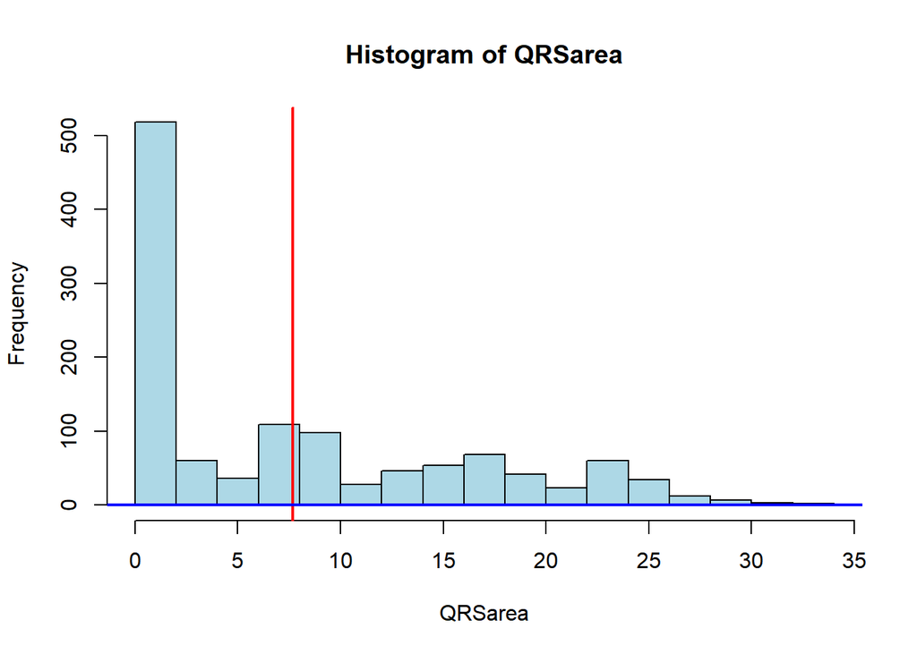

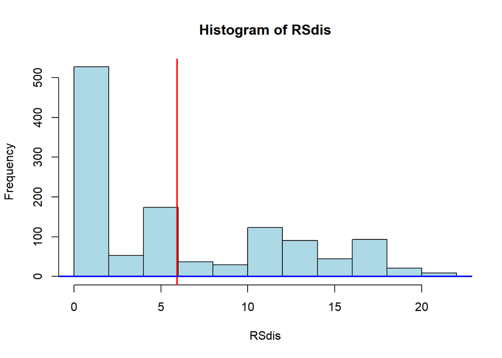

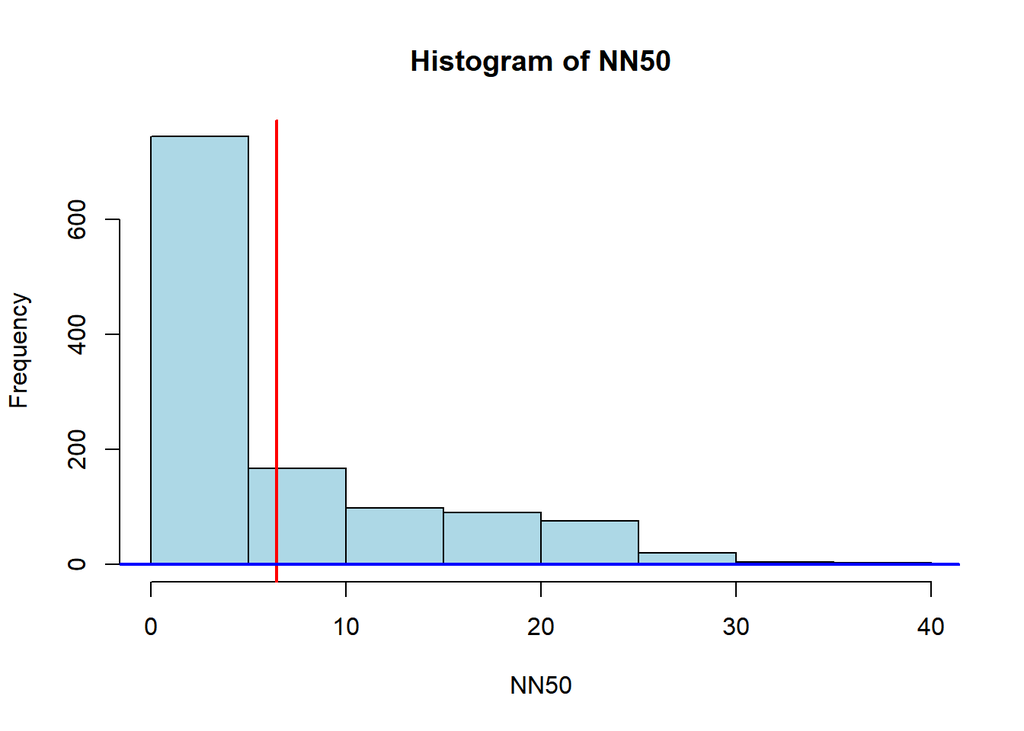

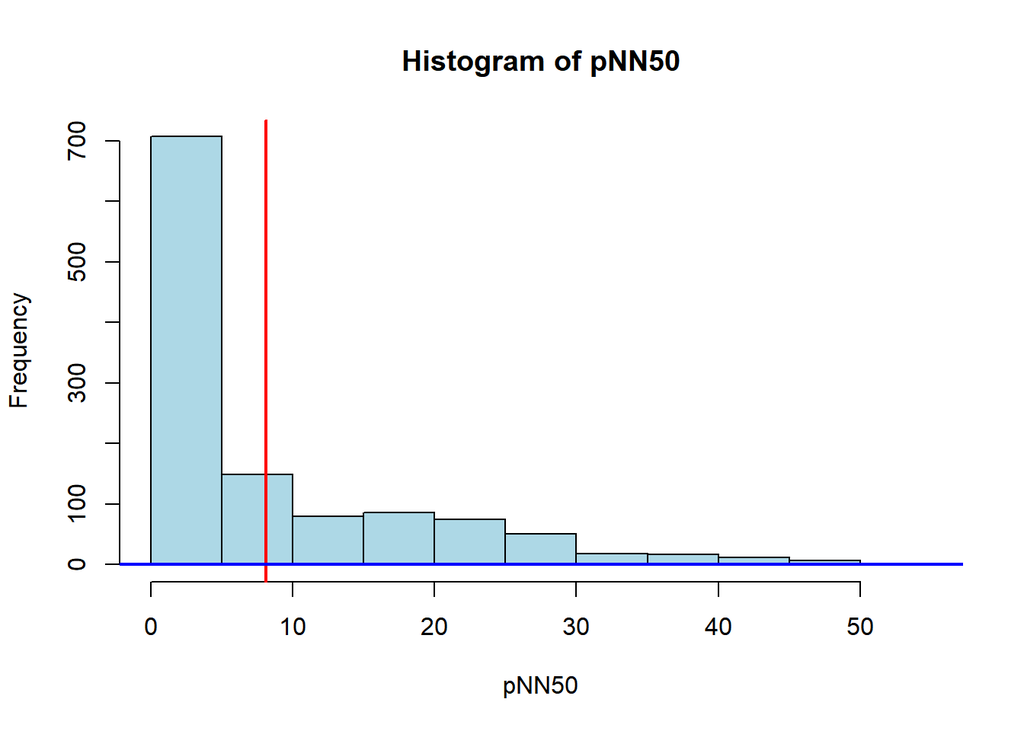

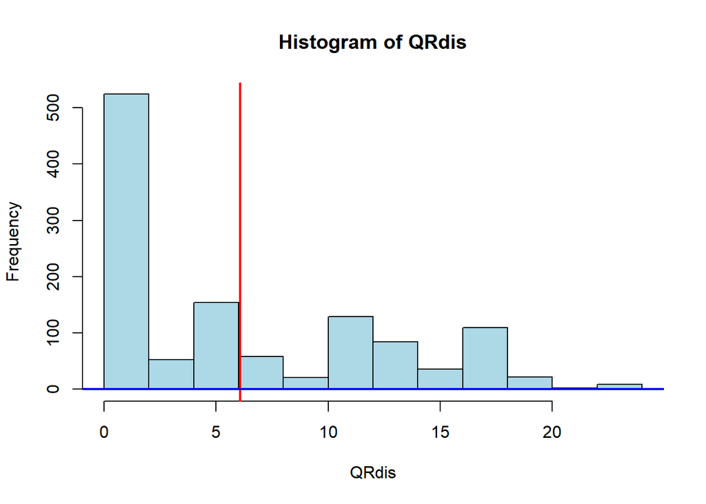

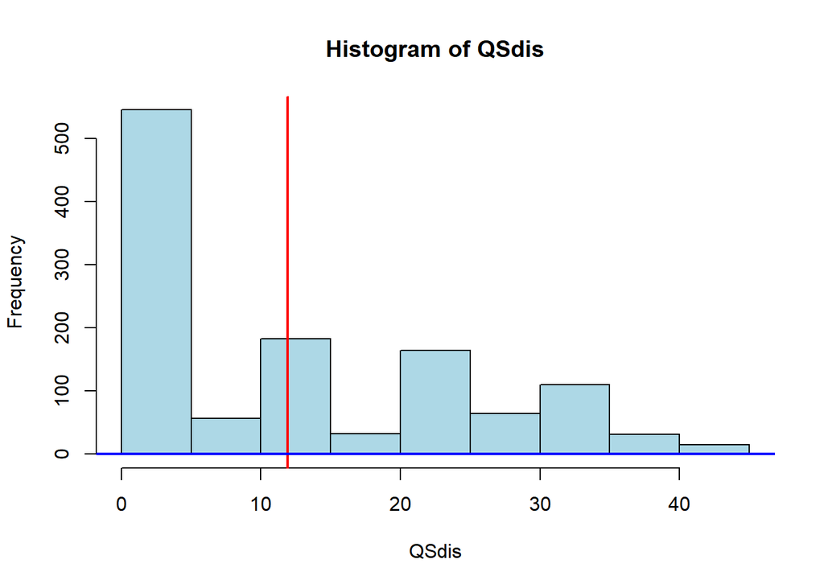

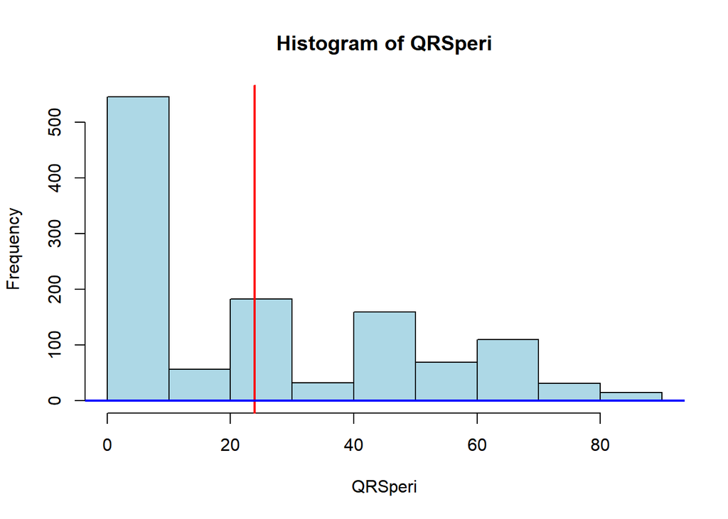

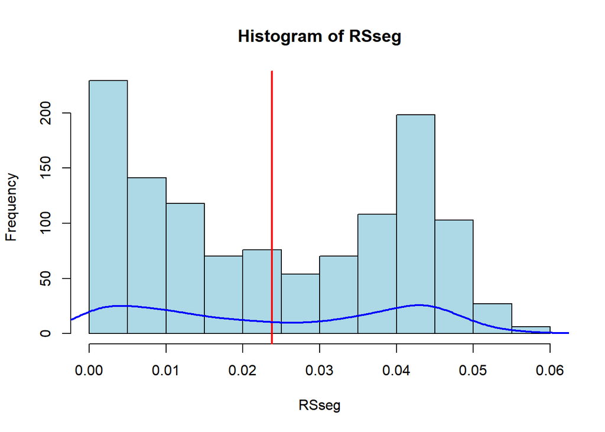

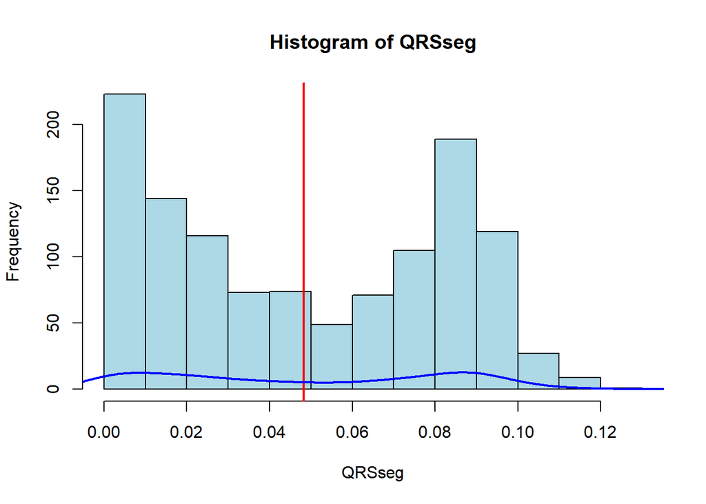

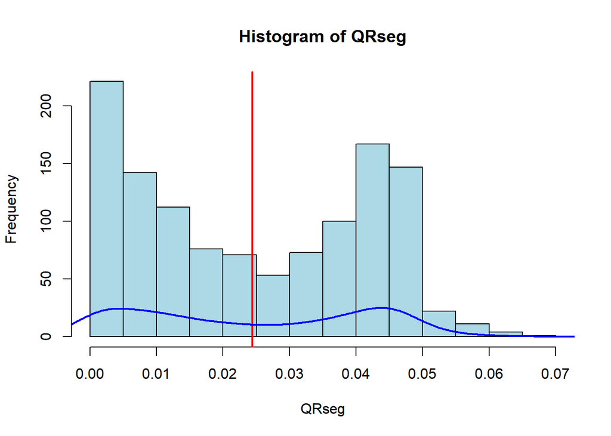

```r
# A continuació analitzarem gràficament les columnes amb 0's

zero_columns <- result_with_zeros_analysis$zero_values
zero_columns_grt1 <- zero_columns$variables_with_zero_data[
  zero_columns$Percentage > 1
]

# Definim una funció per mostrar gràficament la distribució de les variables amb valors 0
plot_zero_columns_grt1 <- function(zero_columns_data) {
  # Filtrem les columnes amb un percentatge de 0's major a l'1%
  zero_columns_grt1 <- zero_columns_data$variables_with_zero_data[
    zero_columns_data$Percentage > 1
  ]

  if (length(zero_columns_grt1) == 0) {
    cat("No columns with zero values greater than 1% to plot.\n")
  } else {
    for (column in zero_columns_grt1) {
      hist(data[[column]], main = paste("Histogram of", column),
           xlab = column, col = "lightblue", border = "black")

      # afegim la mitjana
      abline(v = mean(data[[column]]), col = "red", lwd = 2)

      # afegim una linea de densitat
      lines(density(data[[column]]), col = "blue", lwd = 2)
    }
  }
}

plot_zero_columns_grt1(result_with_zeros_analysis$zero_values)
```

En les variables QRSarea, RSdis, NN50, pNN50, QRdis i QRSperi, la distribució està desviada a la dreta indicant una alta concentració de valors a la part esquerra mentre que a la part dreta, es distribueixen de manera més extensa. En canvi, a les altres variables veiem que la distribució està més compensada tot i que es manté l’alt pes en els valors 0 i a diferència de les altres variables la distribució tendeix a ser bimodal en comptes d’unimodal.

A continuació mostrem els boxplots de les variables numèriques:

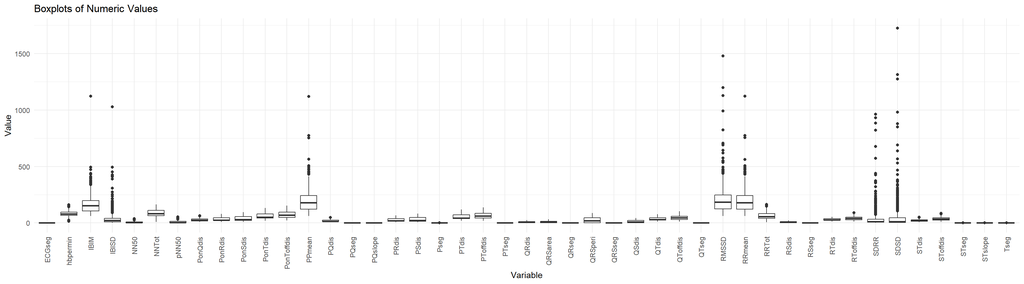

Tal com hem comprovat prèviament amb el resum estadístic, les variables numèriques han de ser normalitzades per equilibrar i homogeneïtzar els pesos de totes elles en una mateixa escala, i d’aquesta manera, reduir l’impacte de valors extrems i millorant la interpretació relativa de cada variable en el model.

A continuació normalitzem les dades:

```r
normalise_min_max <- function(data) {
  numeric_columns <- sapply(data, is.numeric)
  numeric_columns <- numeric_columns & names(data) != "RECORD"
  data_normalised <- data
  data_normalised[, numeric_columns] <- lapply(data_normalised[, numeric_columns], function(x) {
    (x - min(x, na.rm = TRUE)) / (max(x, na.rm = TRUE) - min(x, na.rm = TRUE))
  })

  return(data_normalised)
}

ECGN <- normalise_min_max(ECG_clean)

summary(ECGN)
```

```
##      RECORD          hbpermin           Pseg            PQseg
##  Min.   :   1.0   Min.   :0.0000   Min.   :0.0000   Min.   :0.0000
##  1st Qu.: 300.8   1st Qu.:0.3705   1st Qu.:0.4391   1st Qu.:0.1565
##  Median : 600.5   Median :0.4539   Median :0.5299   Median :0.3034
##  Mean   : 600.5   Mean   :0.4676   Mean   :0.5334   Mean   :0.3322
##  3rd Qu.: 900.2   3rd Qu.:0.5631   3rd Qu.:0.6141   3rd Qu.:0.5014
##  Max.   :1200.0   Max.   :1.0000   Max.   :1.0000   Max.   :1.0000
##      QRSseg           QRseg            QTseg            RSseg
##  Min.   :0.0000   Min.   :0.0000   Min.   :0.0000   Min.   :0.0000
##  1st Qu.:0.1257   1st Qu.:0.1195   1st Qu.:0.1536   1st Qu.:0.1224
##  Median :0.3719   Median :0.3474   Median :0.3405   Median :0.3765
##  Mean   :0.4014   Mean   :0.3744   Mean   :0.3808   Mean   :0.4080
##  3rd Qu.:0.6910   3rd Qu.:0.6421   3rd Qu.:0.6013   3rd Qu.:0.7045
##  Max.   :1.0000   Max.   :1.0000   Max.   :1.0000   Max.   :1.0000
##      STseg             Tseg            PTseg            ECGseg
##  Min.   :0.0000   Min.   :0.0000   Min.   :0.0000   Min.   :0.0000
##  1st Qu.:0.4307   1st Qu.:0.3371   1st Qu.:0.1386   1st Qu.:0.2353
##  Median :0.5283   Median :0.3932   Median :0.3305   Median :0.3935
##  Mean   :0.4758   Mean   :0.4146   Mean   :0.3529   Mean   :0.4022
##  3rd Qu.:0.5675   3rd Qu.:0.4739   3rd Qu.:0.5588   3rd Qu.:0.5670
##  Max.   :1.0000   Max.   :1.0000   Max.   :1.0000   Max.   :1.0000
##      RRmean            PPmean            PQdis           PonQdis
##  Min.   :0.00000   Min.   :0.00000   Min.   :0.0000   Min.   :0.0000
##  1st Qu.:0.05598   1st Qu.:0.05615   1st Qu.:0.1633   1st Qu.:0.1782
##  Median :0.11106   Median :0.11139   Median :0.2042   Median :0.2799
##  Mean   :0.12339   Mean   :0.12365   Mean   :0.3082   Mean   :0.3407
##  3rd Qu.:0.17067   3rd Qu.:0.17036   3rd Qu.:0.4609   3rd Qu.:0.4861
##  Max.   :1.00000   Max.   :1.00000   Max.   :1.0000   Max.   :1.0000
##      PRdis           PonRdis           PSdis            PonSdis
##  Min.   :0.0000   Min.   :0.0000   Min.   :0.00000   Min.   :0.0000
##  1st Qu.:0.1072   1st Qu.:0.1844   1st Qu.:0.08548   1st Qu.:0.1627
##  Median :0.1988   Median :0.2313   Median :0.21370   Median :0.2408
##  Mean   :0.3113   Mean   :0.3470   Mean   :0.31870   Mean   :0.3513
##  3rd Qu.:0.5169   3rd Qu.:0.5219   3rd Qu.:0.53830   3rd Qu.:0.5541
##  Max.   :1.0000   Max.   :1.0000   Max.   :1.00000   Max.   :1.0000
##      PTdis           PonTdis          PToffdis          QRdis
##  Min.   :0.0000   Min.   :0.0000   Min.   :0.0000   Min.   :0.000000
##  1st Qu.:0.1910   1st Qu.:0.1962   1st Qu.:0.1934   1st Qu.:0.002509
##  Median :0.2486   Median :0.2719   Median :0.3585   Median :0.211169
##  Mean   :0.3549   Mean   :0.3685   Mean   :0.3939   Mean   :0.252856
```

[output cut: 29 more lines]

```
##  Max.   :1.00000   Max.   :1.000000   Max.   :1.000000   Max.   :1.00000
##     QRSarea          QRSperi            PQslope          STslope
##  Min.   :0.0000   Min.   :0.000000   Min.   :0.0000   Min.   :0.0000
##  1st Qu.:0.0000   1st Qu.:0.001434   1st Qu.:0.5281   1st Qu.:0.1002
##  Median :0.1578   Median :0.229900   Median :0.7525   Median :0.1680
##  Mean   :0.2317   Mean   :0.276238   Mean   :0.6913   Mean   :0.2140
##  3rd Qu.:0.4333   3rd Qu.:0.533563   3rd Qu.:0.8962   3rd Qu.:0.2659
##  Max.   :1.0000   Max.   :1.000000   Max.   :1.0000   Max.   :1.0000
##       NN50             pNN50          ECG_signal
##  Min.   :0.00000   Min.   :0.00000   Length:1200
##  1st Qu.:0.02703   1st Qu.:0.01164   Class :character
##  Median :0.08108   Median :0.06981   Mode  :character
##  Mean   :0.17412   Mean   :0.15386
##  3rd Qu.:0.27027   3rd Qu.:0.24434
##  Max.   :1.00000   Max.   :1.00000
```

A través del resum estadístic comprovem que les variables numèriques s’han normalitzat correctament i d’aquesta manera podem comparar i analitzar de manera equitativa les diferents variables.

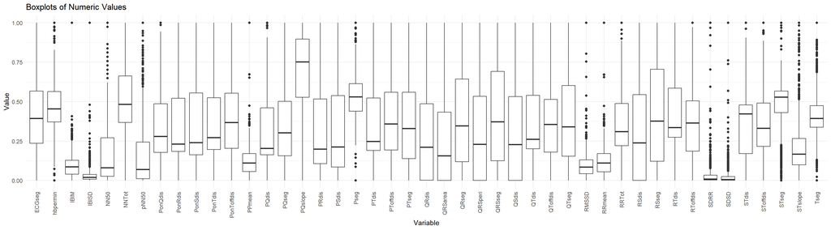

Amb les dades normalitzades, observem una distribució més equitativa i compensada.

A continuació convertirem la classe de chr a factor i durem a terme una breu anàlisi:

```r
class_column <- "ECG_signal"
data <- convert_to_factor(ECGN, class_column)
```

```
##  Factor w/ 4 levels "AFF","ARR","CHF",..: 2 2 2 2 2 2 2 2 2 2 ...
## [1] "AFF" "ARR" "CHF" "NSR"
```

```r
table(ECGN$ECG_signal)
```

```
##
## AFF ARR CHF NSR
## 300 300 300 300
```

La distribució de la classe és homogènia tenint el mateix pes cada una de les classes a predir.

```r
# Selecció de les variables per a la PCA
variables_pca <- ECGN[, -which(names(ECGN) %in% c("ECG_signal", "RECORD"))]

# Aplicació de la PCA
pca_result <- prcomp(variables_pca, center = TRUE, scale = TRUE)

# Resum de la PCA
summary(pca_result)
```

```
## Importance of components:
##                           PC1    PC2     PC3     PC4     PC5     PC6     PC7
## Standard deviation     4.9408 2.9706 1.83863 1.46539 1.16756 1.07565 0.87425
## Proportion of Variance 0.5425 0.1961 0.07512 0.04772 0.03029 0.02571 0.01698
## Cumulative Proportion  0.5425 0.7386 0.81371 0.86143 0.89172 0.91743 0.93442
##                           PC8     PC9    PC10   PC11    PC12    PC13    PC14
## Standard deviation     0.8406 0.72271 0.69312 0.5573 0.47270 0.42186 0.35795
## Proportion of Variance 0.0157 0.01161 0.01068 0.0069 0.00497 0.00395 0.00285
## Cumulative Proportion  0.9501 0.96173 0.97240 0.9793 0.98427 0.98822 0.99107
##                           PC15    PC16    PC17    PC18    PC19   PC20    PC21
## Standard deviation     0.31701 0.30785 0.22460 0.20456 0.17219 0.1637 0.12445
## Proportion of Variance 0.00223 0.00211 0.00112 0.00093 0.00066 0.0006 0.00034
## Cumulative Proportion  0.99330 0.99541 0.99653 0.99746 0.99812 0.9987 0.99906
##                          PC22    PC23    PC24    PC25    PC26    PC27     PC28
## Standard deviation     0.1166 0.10952 0.08264 0.07437 0.06338 0.01830 0.003027
## Proportion of Variance 0.0003 0.00027 0.00015 0.00012 0.00009 0.00001 0.000000
## Cumulative Proportion  0.9994 0.99963 0.99978 0.99990 0.99999 1.00000 1.000000
##                            PC29      PC30      PC31      PC32     PC33
## Standard deviation     0.001927 0.0007307 0.0004049 0.0003106 0.000214
## Proportion of Variance 0.000000 0.0000000 0.0000000 0.0000000 0.000000
## Cumulative Proportion  1.000000 1.0000000 1.0000000 1.0000000 1.000000
##                             PC34     PC35      PC36     PC37      PC38
## Standard deviation     0.0001448 7.87e-05 6.822e-05 4.73e-05 4.113e-05
## Proportion of Variance 0.0000000 0.00e+00 0.000e+00 0.00e+00 0.000e+00
## Cumulative Proportion  1.0000000 1.00e+00 1.000e+00 1.00e+00 1.000e+00
##                             PC39      PC40      PC41      PC42     PC43
## Standard deviation     2.433e-05 1.684e-05 6.946e-06 8.623e-15 6.35e-15
## Proportion of Variance 0.000e+00 0.000e+00 0.000e+00 0.000e+00 0.00e+00
## Cumulative Proportion  1.000e+00 1.000e+00 1.000e+00 1.000e+00 1.00e+00
##                             PC44      PC45
## Standard deviation     2.194e-15 1.486e-15
## Proportion of Variance 0.000e+00 0.000e+00
## Cumulative Proportion  1.000e+00 1.000e+00
```

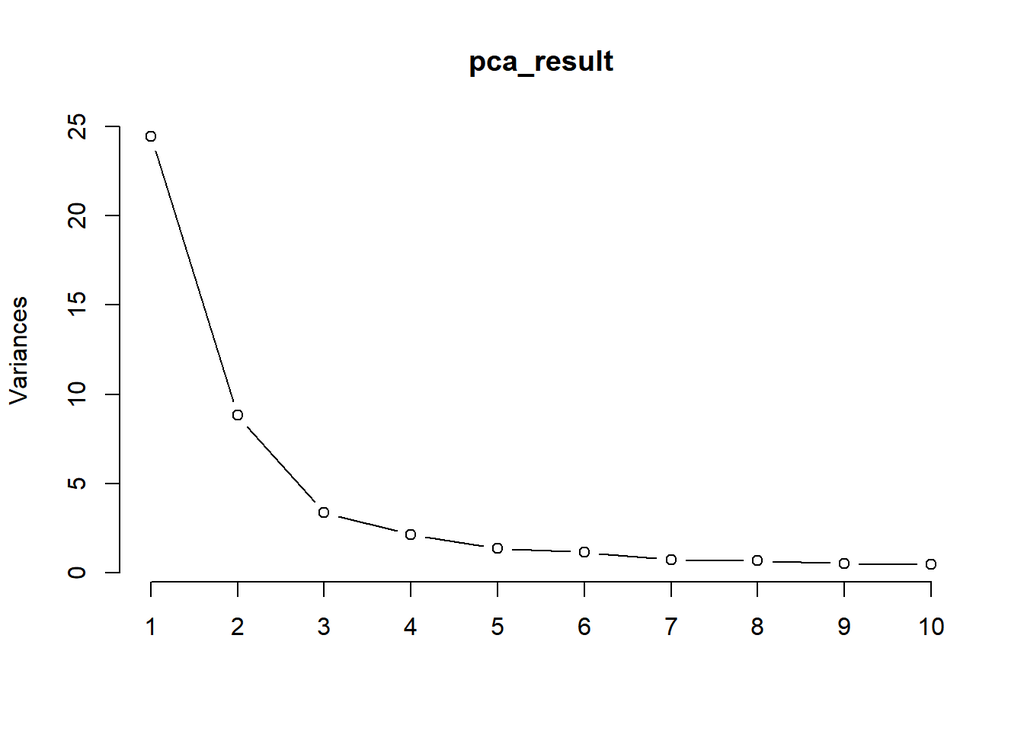

```r
# Gràfic de les variàncies explicades
plot(pca_result, type = "l")
```

A continuació analitzem la variabilitat del ritme cardíac. En primer lloc, seleccionem les variables relacionades amb el ritme cardíac: “SDRR”, “IBIM”, “IBISD”, “SDSD”, “RMSSD”, “QRSarea”, “NN50”, “pNN50”.

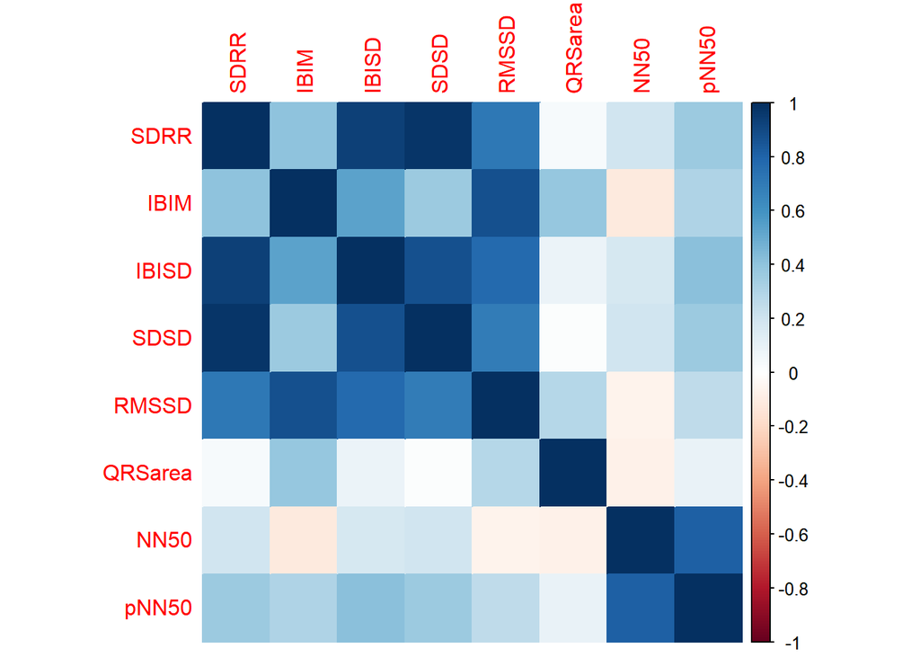

```r
# Selecció de les variables d'HRV
hrv_variables <- ECGN[, c("SDRR", "IBIM", "IBISD", "SDSD", "RMSSD", "QRSarea", "NN50", "pNN50")]

# Normalització de les variables d'HRV
hrv_variables <- scale(hrv_variables)

# Càlcul d'una matriu de correlació per a les variables d'HRV
cor_matrix <- cor(hrv_variables)

# Anàlisi de corbes d'escletxes per a les variables d'HRV
corrplot(cor_matrix, method = "color")
```

A través de la matriu de correlació observem com cada parell de variables està correlacionat entre si. Els valors de correlació varien de -1 a 1, on -1 indica una correlació negativa perfecta, 1 indica una correlació positiva perfecta, i 0 indica la no correlació. Observem que “SDRR”, “IBIM”, “IBISD”, “SDSD”, “RMSSD” tenen força correlació entre si.

A continuació separem les dades en train i test:

```r
# Establim la llavor aleatòria 12345 per garantir la reproductibilitat
set.seed(12345)

# Definim la proporció de dades d'entrenament train
train_proportion <- 0.67

# Creem un índex amb les files d'entrenament
train_index <- sample(1:nrow(ECGN), nrow(ECGN) * train_proportion)

# Separem les dades en conjunts d'entrenament (67%) i de prova (33%)
ECGN_train_data <- ECGN[train_index, ]
ECGN_test_data <- ECGN[-train_index, ]

# Columnes a excloure
columns_to_exclude <- c("RECORD", "ECG_signal")
train_data <- ECGN_train_data[, !(names(ECGN_train_data) %in% columns_to_exclude)]
test_data <- ECGN_test_data[, !(names(ECGN_test_data) %in% columns_to_exclude)]

# Guardem en variables els valors de l'identificador i de la variable a predir (class)
train_IDs <- data.frame(Name = ECGN_train_data[, 0])
test_IDs <- data.frame(Name = ECGN_test_data[, 0])

# Guardem les etiquetes de classe a predir
class_labels <- as.factor(ECGN$ECG_signal)
train_class_labels <- as.factor(ECGN_train_data$ECG_signal)
test_class_labels <- as.factor(ECGN_test_data$ECG_signal)

# Mostrem les primeres files de les dades d'entrenament i de prova juntament amb les etiquetes de classe
# head(train_data)
head(train_class_labels)
```

```
## [1] ARR ARR CHF CHF CHF CHF
## Levels: AFF ARR CHF NSR
```

```r
# head(test_data)
head(test_class_labels)
```

```
## [1] ARR ARR ARR ARR ARR ARR
## Levels: AFF ARR CHF NSR
```

# 3. Sección de aplicación de cada algoritmo para la clasificación. Está formado por subsecciones que corresponden a cada algoritmo y en este orden:

La implementación puede realizarse en R y/o Python. (Puntuación: 60%) En cada algoritmo hay que realizar las etapas mencionadas anteriormente y presentar una tabla de rendimiento de la calidad de la clasificación con al menos tres métricas para los opciones exploradas y un breve comentario.

```r
# creem una funció per obtenir 4 mètriques per tots els models que explorarem
calculate_metrics <- function(conf_matrix) {
  accuracy <- sum(diag(conf_matrix)) / sum(conf_matrix)
  precision <- diag(conf_matrix) / rowSums(conf_matrix)
  recall <- diag(conf_matrix) / colSums(conf_matrix)
  f1_score <- 2 * (precision * recall) / (precision + recall)

  results <- data.frame(
    Accuracy = accuracy,
    Precision = precision,
    Recall = recall,
    F1_Score = f1_score
  )

  return(results)
}

model_results <- list()
```

## • k-Nearest Neighbour. Se explorarán los valores para el número de vecinos k = 1, 3, 5, 7, 11.

El k-NN, o k-Nearest Neighbors és un algorisme basat en el principi de què les instàncies de dades similars tendeixen a existir en proximitat espacial en l’espai de característiques, per tant, es pot predir una nova instància en funció de les seves veïnes més properes. En el cas de classificació, la classe més comuna entre les k veïnes determina la classe de la nova instància.

Definim i avaluem el rendiment de l’algoritme kNN amb els valors de k indicats:

```r
# Definim el vector amb els valors de k que volem provar
k_values <- c(1, 3, 5, 7, 11)

# Creem una llista per emmagatzemar els resultats dels diferents models KNN
knn_algorithm <- list()

# Per cada valor de K, realitzem la predicció i evaluació de les prediccions en una taula de contingència
for (k_val in k_values) {
  # definim el model
  knn_pred <- knn(train = train_data,
                  test = test_data,
                  cl = train_class_labels,
                  k = k_val)
  confusion_matrix <- confusionMatrix(data = as.factor(knn_pred),
                                      reference = as.factor(test_class_labels))
  accuracy <- confusion_matrix$overall["Accuracy"]
  cat("k =", k_val, "Accuracy =", accuracy, "\n")
  cat("Confusion Matrix for k =", k_val, ":\n")
  print(confusion_matrix)
  knn_algorithm[[as.character(k_val)]] <-
    list(accuracy = accuracy,
         confusion_matrix = confusion_matrix,
         predictions = knn_pred)
}
```

```
## k = 1 Accuracy = 0.9722222
## Confusion Matrix for k = 1 :
## Confusion Matrix and Statistics
##
##           Reference
## Prediction AFF ARR CHF NSR
##        AFF 102   0   2   0
##        ARR   0  80   0   0
##        CHF   9   0 104   0
##        NSR   0   0   0  99
##
## Overall Statistics
##
##                Accuracy : 0.9722
##                  95% CI : (0.9508, 0.9861)
##     No Information Rate : 0.2803
##     P-Value [Acc > NIR] : < 2.2e-16
##
##                   Kappa : 0.9628
##
##  Mcnemar's Test P-Value : NA
##
## Statistics by Class:
##
##                      Class: AFF Class: ARR Class: CHF Class: NSR
## Sensitivity              0.9189      1.000     0.9811       1.00
## Specificity              0.9930      1.000     0.9690       1.00
## Pos Pred Value           0.9808      1.000     0.9204       1.00
## Neg Pred Value           0.9692      1.000     0.9929       1.00
## Prevalence               0.2803      0.202     0.2677       0.25
## Detection Rate           0.2576      0.202     0.2626       0.25
## Detection Prevalence     0.2626      0.202     0.2854       0.25
## Balanced Accuracy        0.9560      1.000     0.9750       1.00
## k = 3 Accuracy = 0.9545455
## Confusion Matrix for k = 3 :
## Confusion Matrix and Statistics
##
##           Reference
## Prediction AFF ARR CHF NSR
##        AFF  96   0   3   0
```

[output cut: 110 more lines]

```
##                   Kappa : 0.9019
##
##  Mcnemar's Test P-Value : NA
##
## Statistics by Class:
##
##                      Class: AFF Class: ARR Class: CHF Class: NSR
## Sensitivity              0.8288      1.000     0.9057       1.00
## Specificity              0.9649      1.000     0.9345       1.00
## Pos Pred Value           0.9020      1.000     0.8348       1.00
## Neg Pred Value           0.9354      1.000     0.9644       1.00
## Prevalence               0.2803      0.202     0.2677       0.25
## Detection Rate           0.2323      0.202     0.2424       0.25
## Detection Prevalence     0.2576      0.202     0.2904       0.25
## Balanced Accuracy        0.8969      1.000     0.9201       1.00
```

```r
# Llista per emmagatzemar els resultats dels diferents models KNN
performance_metrics <- list()

# Bucle per cada valor de k
for (k_val in k_values) {
  # Predicció utilitzant l'algoritme k-NN amb el valor actual de k
  knn_pred <- knn(train = train_data, test = test_data, cl = train_class_labels, k = k_val)

  # Creació de la matriu de confusió
  confusion_matrix <- table(Actual = test_class_labels, Predicted = knn_pred)

  # Càlcul de mètriques de rendiment (accuracy, precision, recall, f1_score)
  accuracy <- sum(diag(confusion_matrix)) / sum(confusion_matrix)
  precision <- diag(confusion_matrix) / rowSums(confusion_matrix)
  recall <- diag(confusion_matrix) / colSums(confusion_matrix)
  f1_score <- 2 * (precision * recall) / (precision + recall)

  # Creació d'un dataframe amb els resultats
  results <- data.frame(
    K = k_val,
    Accuracy = accuracy,
    Precision = precision,
    Recall = recall,
    F1_Score = f1_score
  )

  performance_metrics[[as.character(k_val)]] <- results
}

results_knn <- do.call(rbind, performance_metrics)
print(results_knn)
```

```
##         K  Accuracy Precision    Recall  F1_Score
## 1.AFF   1 0.9722222 0.9189189 0.9807692 0.9488372
## 1.ARR   1 0.9722222 1.0000000 1.0000000 1.0000000
## 1.CHF   1 0.9722222 0.9811321 0.9203540 0.9497717
## 1.NSR   1 0.9722222 1.0000000 1.0000000 1.0000000
## 3.AFF   3 0.9545455 0.8648649 0.9696970 0.9142857
## 3.ARR   3 0.9545455 1.0000000 1.0000000 1.0000000
## 3.CHF   3 0.9545455 0.9716981 0.8728814 0.9196429
## 3.NSR   3 0.9545455 1.0000000 1.0000000 1.0000000
## 5.AFF   5 0.9393939 0.8198198 0.9578947 0.8834951
## 5.ARR   5 0.9393939 1.0000000 1.0000000 1.0000000
## 5.CHF   5 0.9393939 0.9622642 0.8360656 0.8947368
## 5.NSR   5 0.9393939 1.0000000 1.0000000 1.0000000
## 7.AFF   7 0.9419192 0.8288288 0.9583333 0.8888889
## 7.ARR   7 0.9419192 1.0000000 1.0000000 1.0000000
## 7.CHF   7 0.9419192 0.9622642 0.8429752 0.8986784
## 7.NSR   7 0.9419192 1.0000000 1.0000000 1.0000000
## 11.AFF 11 0.9267677 0.8288288 0.9019608 0.8638498
## 11.ARR 11 0.9267677 1.0000000 1.0000000 1.0000000
## 11.CHF 11 0.9267677 0.9056604 0.8347826 0.8687783
## 11.NSR 11 0.9267677 1.0000000 1.0000000 1.0000000
```

## • Naive Bayes. Se explorará la opción de activar o no laplace.

L’algoritme de Naive Bayes descriu un mètode per aplicar el teorema de Bayes en problemes de classificació. Destaca per ser ràpid, sense gaire complexitat i gestionar correctament dades amb soroll i NAs. L’algoritme de Naive Bayes assumeix que totes les variables són igualment importants e independents, fet que el fa força versàtil.

Quan diem d’activar laplace, ens referim a afegir un número petit en la taula de freqüències, de manera que cada variable mai té una probabilitat del 0%. Normalment s’activa amb un 1, fet que assegura que totes les combinacions entre classes i variables apareixen mínim una vegada.

Per aplicar l’algoritme de Naive Bayes utilitzarem la funció NaiveBayes() del paquet e1071.

```r
# Definim el model sense activar laplace
naiveBayes_m <- naiveBayes(train_data, train_class_labels, laplace = 0)

# Realitzem les prediccions pel model sense activar laplace
naiveBayes_pred <- predict(naiveBayes_m, test_data)
CrossTable(naiveBayes_pred, test_class_labels,
           prop.chisq = FALSE, prop.t = FALSE,
           dnn = c('predicted', 'actual'))
```

```
##
##
##    Cell Contents
## |-------------------------|
## |                       N |
## |           N / Row Total |
## |           N / Col Total |
## |-------------------------|
##
##
## Total Observations in Table:  396
##
##
##              | actual
##    predicted |       AFF |       ARR |       CHF |       NSR | Row Total |
## -------------|-----------|-----------|-----------|-----------|-----------|
##          AFF |        88 |        12 |        21 |         2 |       123 |
##              |     0.715 |     0.098 |     0.171 |     0.016 |     0.311 |
##              |     0.793 |     0.150 |     0.198 |     0.020 |           |
## -------------|-----------|-----------|-----------|-----------|-----------|
##          ARR |         2 |        68 |         0 |         0 |        70 |
##              |     0.029 |     0.971 |     0.000 |     0.000 |     0.177 |
##              |     0.018 |     0.850 |     0.000 |     0.000 |           |
## -------------|-----------|-----------|-----------|-----------|-----------|
##          CHF |        21 |         0 |        85 |         0 |       106 |
##              |     0.198 |     0.000 |     0.802 |     0.000 |     0.268 |
##              |     0.189 |     0.000 |     0.802 |     0.000 |           |
## -------------|-----------|-----------|-----------|-----------|-----------|
##          NSR |         0 |         0 |         0 |        97 |        97 |
##              |     0.000 |     0.000 |     0.000 |     1.000 |     0.245 |
##              |     0.000 |     0.000 |     0.000 |     0.980 |           |
## -------------|-----------|-----------|-----------|-----------|-----------|
## Column Total |       111 |        80 |       106 |        99 |       396 |
##              |     0.280 |     0.202 |     0.268 |     0.250 |           |
## -------------|-----------|-----------|-----------|-----------|-----------|
##
##
```

```r
# creem les matrius de confusió i mètriques
confusionMatrix(naiveBayes_pred, test_class_labels)
```

```
## Confusion Matrix and Statistics
##
##           Reference
## Prediction AFF ARR CHF NSR
##        AFF  88  12  21   2
##        ARR   2  68   0   0
##        CHF  21   0  85   0
##        NSR   0   0   0  97
##
## Overall Statistics
##
##                Accuracy : 0.8535
##                  95% CI : (0.8148, 0.8869)
##     No Information Rate : 0.2803
##     P-Value [Acc > NIR] : < 2.2e-16
##
##                   Kappa : 0.8032
##
##  Mcnemar's Test P-Value : NA
##
## Statistics by Class:
##
##                      Class: AFF Class: ARR Class: CHF Class: NSR
## Sensitivity              0.7928     0.8500     0.8019     0.9798
## Specificity              0.8772     0.9937     0.9276     1.0000
## Pos Pred Value           0.7154     0.9714     0.8019     1.0000
## Neg Pred Value           0.9158     0.9632     0.9276     0.9933
## Prevalence               0.2803     0.2020     0.2677     0.2500
## Detection Rate           0.2222     0.1717     0.2146     0.2449
## Detection Prevalence     0.3106     0.1768     0.2677     0.2449
## Balanced Accuracy        0.8350     0.9218     0.8647     0.9899
```

```r
confusion_matrix_naiveBayes <- table(Actual = test_class_labels,
                                     Predicted = naiveBayes_pred)

results_naiveBayes <- calculate_metrics(confusion_matrix_naiveBayes)
results_naiveBayes
```

```
##      Accuracy Precision    Recall  F1_Score
## AFF 0.8535354 0.7927928 0.7154472 0.7521368
## ARR 0.8535354 0.8500000 0.9714286 0.9066667
## CHF 0.8535354 0.8018868 0.8018868 0.8018868
## NSR 0.8535354 0.9797980 1.0000000 0.9897959
```

```r
# Definim el model activant laplace = 1
naiveBayesLap_m <- naiveBayes(train_data, train_class_labels, laplace = 1)

# Realitzem les prediccións del model amb laplace activat
naiveBayesLap_pred <- predict(naiveBayesLap_m, test_data)
CrossTable(naiveBayesLap_pred, test_class_labels,
           prop.chisq = FALSE, prop.t = FALSE,
           dnn = c('predicted', 'actual'))
```

```
##
##
##    Cell Contents
## |-------------------------|
## |                       N |
## |           N / Row Total |
## |           N / Col Total |
## |-------------------------|
##
##
## Total Observations in Table:  396
##
##
##              | actual
##    predicted |       AFF |       ARR |       CHF |       NSR | Row Total |
## -------------|-----------|-----------|-----------|-----------|-----------|
##          AFF |        88 |        12 |        21 |         2 |       123 |
##              |     0.715 |     0.098 |     0.171 |     0.016 |     0.311 |
##              |     0.793 |     0.150 |     0.198 |     0.020 |           |
## -------------|-----------|-----------|-----------|-----------|-----------|
##          ARR |         2 |        68 |         0 |         0 |        70 |
##              |     0.029 |     0.971 |     0.000 |     0.000 |     0.177 |
##              |     0.018 |     0.850 |     0.000 |     0.000 |           |
## -------------|-----------|-----------|-----------|-----------|-----------|
##          CHF |        21 |         0 |        85 |         0 |       106 |
##              |     0.198 |     0.000 |     0.802 |     0.000 |     0.268 |
##              |     0.189 |     0.000 |     0.802 |     0.000 |           |
## -------------|-----------|-----------|-----------|-----------|-----------|
##          NSR |         0 |         0 |         0 |        97 |        97 |
##              |     0.000 |     0.000 |     0.000 |     1.000 |     0.245 |
##              |     0.000 |     0.000 |     0.000 |     0.980 |           |
## -------------|-----------|-----------|-----------|-----------|-----------|
## Column Total |       111 |        80 |       106 |        99 |       396 |
##              |     0.280 |     0.202 |     0.268 |     0.250 |           |
## -------------|-----------|-----------|-----------|-----------|-----------|
##
##
```

```r
confusionMatrix(naiveBayesLap_pred, test_class_labels)
```

```
## Confusion Matrix and Statistics
##
##           Reference
## Prediction AFF ARR CHF NSR
##        AFF  88  12  21   2
##        ARR   2  68   0   0
##        CHF  21   0  85   0
##        NSR   0   0   0  97
##
## Overall Statistics
##
##                Accuracy : 0.8535
##                  95% CI : (0.8148, 0.8869)
##     No Information Rate : 0.2803
##     P-Value [Acc > NIR] : < 2.2e-16
##
##                   Kappa : 0.8032
##
##  Mcnemar's Test P-Value : NA
##
## Statistics by Class:
##
##                      Class: AFF Class: ARR Class: CHF Class: NSR
## Sensitivity              0.7928     0.8500     0.8019     0.9798
## Specificity              0.8772     0.9937     0.9276     1.0000
## Pos Pred Value           0.7154     0.9714     0.8019     1.0000
## Neg Pred Value           0.9158     0.9632     0.9276     0.9933
## Prevalence               0.2803     0.2020     0.2677     0.2500
## Detection Rate           0.2222     0.1717     0.2146     0.2449
## Detection Prevalence     0.3106     0.1768     0.2677     0.2449
## Balanced Accuracy        0.8350     0.9218     0.8647     0.9899
```

```r
confusion_matrix_naiveBayesLap <- table(Actual = test_class_labels,
                                        Predicted = naiveBayesLap_pred)

results_naiveBayesLap <- calculate_metrics(confusion_matrix_naiveBayesLap)
results_naiveBayesLap
```

```
##      Accuracy Precision    Recall  F1_Score
## AFF 0.8535354 0.7927928 0.7154472 0.7521368
## ARR 0.8535354 0.8500000 0.9714286 0.9066667
## CHF 0.8535354 0.8018868 0.8018868 0.8018868
## NSR 0.8535354 0.9797980 1.0000000 0.9897959
```

Si observem els resultats, veiem que activar laplace en aquest cas no altera els resultats del model i que els dos models obtenen els mateixos resultats.

## • Artificial Neural Network. Se explorarán las arquitecturas con una y dos capas ocultas: 1) con 15 nodos en una capa oculta, 2) 25 y 10 nodos en cada capa oculta.

L’algoritme de xarxa neuronal artificial, és un model computacional inspirat en un origen en l’estructura i el funcionament del sistema nerviós biològic. Es tracta en capes de nodes interconnectats sent l’estructura: capes d’entrada, capes ocultes i capes de sortida. Cada node té un pes associat que determina la força de la influència d’una neurona sobre l’altre. Durant l’entrenament del model, aquests pesos són ajustats.

Per aplicar l’algoritme utilitzarem la funció neuralnet() del paquet homònim neuralnet.

```r
if (!require(neuralnet)) {
  install.packages("neuralnet")
  library(neuralnet)
}

# Per utilitzar la funció neuralnet, hem de combinar les variables predictores i la classe a predir en un mateix dataset, i convertir la classe a tipus numèric
train_data_with_labels <- cbind(train_data, train_class_labels)
test_data_with_labels <- cbind(test_data, test_class_labels)

# DEFINICIO MODEL AMB NEURALNET() 15 NODOS EN UNA CAPA OCULTA
# Definim el model amb una capa oculta de 15 nodes (hidden = 15)
ann_m_15nodes <- neuralnet(
  train_class_labels ~ .,
  data = train_data_with_labels,
  hidden = 15,
  linear.output = FALSE
)

# visualitzem l'estructura de la xarxa neuronal del model definit amb una capa oculta de 15 nodes
plot(ann_m_15nodes)


test_data_with_labels$test_class_labels <- as.factor(test_data_with_labels$test_class_labels)

test_data_with_labels$test_class_labels <- as.numeric(test_data_with_labels$test_class_labels)

# Fem prediccions amb les dades de test
model_results <- predict(ann_m_15nodes, test_data_with_labels[0:45])
predicted_values <- as.matrix(model_results)
predicted_classes <- apply(predicted_values, 1, which.max)

# Calculem la correlació i mostrem la matriu de confusió
cor(predicted_classes, test_data_with_labels$test_class_labels)
```

[output not shown]

```
## [1] 0.9515207
```

```r
confusionMatrix(table(predicted_classes, test_data_with_labels$test_class_labels))
```

```
## Confusion Matrix and Statistics
##
##
## predicted_classes   1   2   3   4
##                 1 104   0   3   1
##                 2   0  80   1   0
##                 3   7   0 102   0
##                 4   0   0   0  98
##
## Overall Statistics
##
##                Accuracy : 0.9697
##                  95% CI : (0.9477, 0.9842)
##     No Information Rate : 0.2803
##     P-Value [Acc > NIR] : < 2.2e-16
##
##                   Kappa : 0.9594
##
##  Mcnemar's Test P-Value : NA
##
## Statistics by Class:
##
##                      Class: 1 Class: 2 Class: 3 Class: 4
## Sensitivity            0.9369   1.0000   0.9623   0.9899
## Specificity            0.9860   0.9968   0.9759   1.0000
## Pos Pred Value         0.9630   0.9877   0.9358   1.0000
## Neg Pred Value         0.9757   1.0000   0.9861   0.9966
## Prevalence             0.2803   0.2020   0.2677   0.2500
## Detection Rate         0.2626   0.2020   0.2576   0.2475
## Detection Prevalence   0.2727   0.2045   0.2753   0.2475
## Balanced Accuracy      0.9615   0.9984   0.9691   0.9949
```

Realitzem el mateix pel model amb dues capes ocultes:

```r
# Definim el model amb dues capes ocultes
ann_m_2510nodes <- neuralnet(
  train_class_labels ~ .,
  data = train_data_with_labels,
  hidden = c(25, 10),
  linear.output = TRUE
)

plot(ann_m_2510nodes)

test_data_with_labels$test_class_labels <- as.factor(test_data_with_labels$test_class_labels)

test_data_with_labels$test_class_labels <- as.numeric(test_data_with_labels$test_class_labels)

# Fem prediccions amb les dades de test
model_results <- predict(ann_m_2510nodes, test_data_with_labels[0:45])

predicted_values <- as.matrix(model_results)
predicted_classes <- apply(predicted_values, 1, which.max)

# Calculem la correlació i mostrem la matriu de confusió
cor(predicted_classes, test_data_with_labels$test_class_labels)
```

[output not shown]

```
## [1] 0.9419173
```

```r
confusionMatrix(table(predicted_classes, test_data_with_labels$test_class_labels))
```

```
## Confusion Matrix and Statistics
##
##
## predicted_classes   1   2   3   4
##                 1 101   0   5   0
##                 2   0  80   0   0
##                 3  10   0 101   0
##                 4   0   0   0  99
##
## Overall Statistics
##
##                Accuracy : 0.9621
##                  95% CI : (0.9383, 0.9786)
##     No Information Rate : 0.2803
##     P-Value [Acc > NIR] : < 2.2e-16
##
##                   Kappa : 0.9493
##
##  Mcnemar's Test P-Value : NA
##
## Statistics by Class:
##
##                      Class: 1 Class: 2 Class: 3 Class: 4
## Sensitivity            0.9099    1.000   0.9528     1.00
## Specificity            0.9825    1.000   0.9655     1.00
## Pos Pred Value         0.9528    1.000   0.9099     1.00
## Neg Pred Value         0.9655    1.000   0.9825     1.00
## Prevalence             0.2803    0.202   0.2677     0.25
## Detection Rate         0.2551    0.202   0.2551     0.25
## Detection Prevalence   0.2677    0.202   0.2803     0.25
## Balanced Accuracy      0.9462    1.000   0.9592     1.00
```

L’accuracy del segon model amb dues capes ocultes (96,21%) és menor que la del model amb una capa oculta (96,97%), tot i que ambdós resultats són molt elevats i en el cas d’algunes classes, la predicció a les dades de test és exacta.

## • Support Vector Machine. Se explorarán la funciones kernel lineal y rbf.

Les Màquines de Suport Vectorial (SVM, per les seves sigles en anglès) són un tipus de model d’aprenentatge automàtic que es basen a identificar un hiperplà en l’espai de característiques que millor separi les instàncies de diferents classes. Una característica clau és la transformació de les dades originals en un espai de característiques de dimensions més altes. Aquest hiperplà és seleccionat de manera que la distància entre les instàncies més properes de les dues classes, anomenades vectors de suport, sigui màxima.

Creem el model amb el kernel lineal utilitzant la funció ksvm() de la llibreria kernlab, realitzem les prediccions sobre les dades de prova test i mostrem els resultats.

```r
# Definim el model SVM lineal
linear_svm_m <- ksvm(train_class_labels ~ .,
                     data = train_data,
                     kernel = "vanilladot",
                     C = 0.01)
# Realitzem la predicció de les classes sobre les dades de prova (test)
linear_svm_pred <- predict(linear_svm_m, test_data)

# Imprimim la matriu de confusió
confusionMatrix(linear_svm_pred, test_class_labels)
```

```
## Confusion Matrix and Statistics
##
##           Reference
## Prediction AFF ARR CHF NSR
##        AFF  96   0  20   0
##        ARR   0  80   0   0
##        CHF  15   0  86   0
##        NSR   0   0   0  99
##
## Overall Statistics
##
##                Accuracy : 0.9116
##                  95% CI : (0.8792, 0.9377)
##     No Information Rate : 0.2803
##     P-Value [Acc > NIR] : < 2.2e-16
##
##                   Kappa : 0.8816
##
##  Mcnemar's Test P-Value : NA
##
## Statistics by Class:
##
##                      Class: AFF Class: ARR Class: CHF Class: NSR
## Sensitivity              0.8649      1.000     0.8113       1.00
## Specificity              0.9298      1.000     0.9483       1.00
## Pos Pred Value           0.8276      1.000     0.8515       1.00
## Neg Pred Value           0.9464      1.000     0.9322       1.00
## Prevalence               0.2803      0.202     0.2677       0.25
## Detection Rate           0.2424      0.202     0.2172       0.25
## Detection Prevalence     0.2929      0.202     0.2551       0.25
## Balanced Accuracy        0.8973      1.000     0.8798       1.00
```

```r
confusion_matrix_linear_svm <- table(linear_svm_pred, test_class_labels)

# Evaluem la precisió del model
metrics_linear_svm <- calculate_metrics(confusion_matrix_linear_svm)
print("Mètriques per al model SVM lineal:")
```

```
## [1] "Mètriques per al model SVM lineal:"
```

```r
print(metrics_linear_svm)
```

```
##      Accuracy Precision    Recall  F1_Score
## AFF 0.9116162 0.8275862 0.8648649 0.8458150
## ARR 0.9116162 1.0000000 1.0000000 1.0000000
## CHF 0.9116162 0.8514851 0.8113208 0.8309179
## NSR 0.9116162 1.0000000 1.0000000 1.0000000
```

La matriu de confusió obtinguda en avaluar el model revela un rendiment general força alt, amb una accuracy del 91.16%. Si observem les altes sensibilitats i especificitats per a cada classe, s’evidencia una bona capacitat del model de distinció entre les classes. Les classes ARR i NSR són predites al 100%, amb una sensibilitat i especificitat del 100%. Això no obstant, les variables AFF i CHF tenen una sensibilitat i especificitat menor.

A continuació definirem un segon model SVM lineal ajustant alguns hiperparàmetres i aplicant la validació creuada.

```r
# Creem i entrenem el model SVM lineal amb el millor C
linear_svm_mcar <- train(x = train_data,
                          y = train_class_labels,
                          method = "svmLinear",
                          trControl = trainControl(method = "cv", number = 3)
                          )

# Realitzem la predicció de les classes sobre les dades de prova (test)
linear_svm_mcar_pred <- predict(linear_svm_mcar, test_data)

# Imprimim la matriu de confusió i valors estadístics del model
confusionMatrix(linear_svm_mcar_pred, test_class_labels)
```

```
## Confusion Matrix and Statistics
##
##           Reference
## Prediction AFF ARR CHF NSR
##        AFF  96   0   1   1
##        ARR   0  80   0   0
##        CHF  15   0 105   0
##        NSR   0   0   0  98
##
## Overall Statistics
##
##                Accuracy : 0.9571
##                  95% CI : (0.9322, 0.9748)
##     No Information Rate : 0.2803
##     P-Value [Acc > NIR] : < 2.2e-16
##
##                   Kappa : 0.9425
##
##  Mcnemar's Test P-Value : NA
##
## Statistics by Class:
##
##                      Class: AFF Class: ARR Class: CHF Class: NSR
## Sensitivity              0.8649      1.000     0.9906     0.9899
## Specificity              0.9930      1.000     0.9483     1.0000
## Pos Pred Value           0.9796      1.000     0.8750     1.0000
## Neg Pred Value           0.9497      1.000     0.9964     0.9966
## Prevalence               0.2803      0.202     0.2677     0.2500
## Detection Rate           0.2424      0.202     0.2652     0.2475
## Detection Prevalence     0.2475      0.202     0.3030     0.2475
## Balanced Accuracy        0.9289      1.000     0.9694     0.9949
```

```r
confusion_matrix_lin_svm_adj <- table(linear_svm_mcar_pred, test_class_labels)

# Evaluem la precisió del model
metrics_linear_svm_adj <- calculate_metrics(confusion_matrix_lin_svm_adj)
print("Mètriques per al model SVM lineal ajustat:")
```

```
## [1] "Mètriques per al model SVM lineal ajustat:"
```

```r
print(metrics_linear_svm_adj)
```

```
##      Accuracy Precision    Recall  F1_Score
## AFF 0.9570707 0.9795918 0.8648649 0.9186603
## ARR 0.9570707 1.0000000 1.0000000 1.0000000
## CHF 0.9570707 0.8750000 0.9905660 0.9292035
## NSR 0.9570707 1.0000000 0.9898990 0.9949239
```

El model SVM lineal amb crossvalidation mostra una major precisió global en comparació amb el model anterior, indicant una major capacitat de classificació. A més, el valor de Kappa també és superior, indicant una major concordança entre les prediccions del model i les observacions reals. Si observem les estadístiques per cada classe, la classe CHF mostra una important millora en la seva capacitat de predicció.

A continuació definim el model amb kernel RBF.

```r
# Creem i entrenem el model SVM amb kernel RBF
rbf_svm_m <- ksvm(train_class_labels ~ .,
                      data = train_data,
                      kernel = "rbfdot")

# Realitzem la predicció de les classes sobre les dades de prova (test)
rbf_svm_pred <- predict(rbf_svm_m, test_data)

# Imprimim la matriu de confusió i valors estadístics del model
confusionMatrix(rbf_svm_pred, test_class_labels)
```

```
## Confusion Matrix and Statistics
##
##           Reference
## Prediction AFF ARR CHF NSR
##        AFF  96   0   3   0
##        ARR   0  80   0   1
##        CHF  15   0 103   0
##        NSR   0   0   0  98
##
## Overall Statistics
##
##                Accuracy : 0.952
##                  95% CI : (0.9261, 0.9709)
##     No Information Rate : 0.2803
##     P-Value [Acc > NIR] : < 2.2e-16
##
##                   Kappa : 0.9358
##
##  Mcnemar's Test P-Value : NA
##
## Statistics by Class:
##
##                      Class: AFF Class: ARR Class: CHF Class: NSR
## Sensitivity              0.8649     1.0000     0.9717     0.9899
## Specificity              0.9895     0.9968     0.9483     1.0000
## Pos Pred Value           0.9697     0.9877     0.8729     1.0000
## Neg Pred Value           0.9495     1.0000     0.9892     0.9966
## Prevalence               0.2803     0.2020     0.2677     0.2500
## Detection Rate           0.2424     0.2020     0.2601     0.2475
## Detection Prevalence     0.2500     0.2045     0.2980     0.2475
## Balanced Accuracy        0.9272     0.9984     0.9600     0.9949
```

```r
confusion_matrix_rbf_svm <- table(rbf_svm_pred, test_class_labels)

# Evaluem la precisió del model
metrics_rbf_svm <- calculate_metrics(confusion_matrix_rbf_svm)
print("Mètriques per al model SVM amb kernel RBF:")
```

```
## [1] "Mètriques per al model SVM amb kernel RBF:"
```

```r
print(metrics_rbf_svm)
```

```
##      Accuracy Precision    Recall  F1_Score
## AFF 0.9520202 0.9696970 0.8648649 0.9142857
## ARR 0.9520202 0.9876543 1.0000000 0.9937888
## CHF 0.9520202 0.8728814 0.9716981 0.9196429
## NSR 0.9520202 1.0000000 0.9898990 0.9949239
```

L’algoritme SVM amb kernel RBF mostra una accuracy força similar al model SVM lineal amb validació creuada. Tanmateix, el model RBF presenta un bon equilibri entre sensibilitat i especificitat per a totes les classes, la qual cosa suggereix la seva capacitat per a identificar tant instàncies positives com negatives de manera efectiva.

A continuació realitzarem una cerca dels hiperparàmetres més adients per l’algoritme SVM RBF:

```r
# Definim l'abast d'hiperparàmetres a explorar
hyperparameters <- expand.grid(.sigma = seq(0.005, 0.5, by = 0.05),
                               .C = seq(0.1, 2, by = 0.2))

# Entrenem el model SVM amb kernel RBF amb els diferents hiperparàmetres definits utilitzant caret
rbf_svm_grid <- train(x = train_data,
                       y = train_class_labels,
                       method = "svmRadial",
                       tuneGrid = hyperparameters)

# Imprimim i guardem els resultats
print(rbf_svm_grid)
```

```
## Support Vector Machines with Radial Basis Function Kernel
##
## 804 samples
##  45 predictor
##   4 classes: 'AFF', 'ARR', 'CHF', 'NSR'
##
## No pre-processing
## Resampling: Bootstrapped (25 reps)
## Summary of sample sizes: 804, 804, 804, 804, 804, 804, ...
## Resampling results across tuning parameters:
##
##   sigma  C    Accuracy   Kappa
##   0.005  0.1  0.8532853  0.8044950
##   0.005  0.3  0.9221354  0.8959564
##   0.005  0.5  0.9301016  0.9065955
##   0.005  0.7  0.9328531  0.9102671
##   0.005  0.9  0.9364086  0.9150193
##   0.005  1.1  0.9390359  0.9185322
##   0.005  1.3  0.9412259  0.9214573
##   0.005  1.5  0.9432857  0.9242173
##   0.005  1.7  0.9453528  0.9269809
##   0.005  1.9  0.9468623  0.9289991
##   0.055  0.1  0.9257604  0.9007901
##   0.055  0.3  0.9481543  0.9307101
##   0.055  0.5  0.9603520  0.9470199
##   0.055  0.7  0.9673450  0.9563656
##   0.055  0.9  0.9710478  0.9613132
##   0.055  1.1  0.9725308  0.9632917
##   0.055  1.3  0.9732104  0.9641980
##   0.055  1.5  0.9744486  0.9658488
##   0.055  1.7  0.9763770  0.9684274
##   0.055  1.9  0.9774703  0.9698878
##   0.105  0.1  0.9213687  0.8948899
##   0.105  0.3  0.9502291  0.9334614
##   0.105  0.5  0.9633505  0.9510034
##   0.105  0.7  0.9685722  0.9579848
##   0.105  0.9  0.9721149  0.9627198
##   0.105  1.1  0.9739027  0.9651092
##   0.105  1.3  0.9756801  0.9674861
##   0.105  1.5  0.9763643  0.9684027
```

[output cut: 60 more lines]

```
##   0.405  1.7  0.9326660  0.9098214
##   0.405  1.9  0.9327993  0.9100006
##   0.455  0.1  0.5452148  0.3864765
##   0.455  0.3  0.8389924  0.7839130
##   0.455  0.5  0.8893104  0.8515392
##   0.455  0.7  0.9064244  0.8745680
##   0.455  0.9  0.9153086  0.8865049
##   0.455  1.1  0.9199767  0.8927732
##   0.455  1.3  0.9225873  0.8962816
##   0.455  1.5  0.9236929  0.8977597
##   0.455  1.7  0.9236911  0.8977589
##   0.455  1.9  0.9235564  0.8975791
##
## Accuracy was used to select the optimal model using the largest value.
## The final values used for the model were sigma = 0.055 and C = 1.9.
```

```r
grid_results <- rbf_svm_grid$results
grid_results
```

```
##     sigma   C  Accuracy     Kappa  AccuracySD    KappaSD
## 1   0.005 0.1 0.8532853 0.8044950 0.035536828 0.04695838
## 2   0.005 0.3 0.9221354 0.8959564 0.015892407 0.02121781
## 3   0.005 0.5 0.9301016 0.9065955 0.013359245 0.01779699
## 4   0.005 0.7 0.9328531 0.9102671 0.012740865 0.01697483
## 5   0.005 0.9 0.9364086 0.9150193 0.012279879 0.01635545
## 6   0.005 1.1 0.9390359 0.9185322 0.012165459 0.01619482
## 7   0.005 1.3 0.9412259 0.9214573 0.012353172 0.01646028
## 8   0.005 1.5 0.9432857 0.9242173 0.012189236 0.01623092
## 9   0.005 1.7 0.9453528 0.9269809 0.012469133 0.01658404
## 10  0.005 1.9 0.9468623 0.9289991 0.012952569 0.01724276
## 11  0.055 0.1 0.9257604 0.9007901 0.012936424 0.01725524
## 12  0.055 0.3 0.9481543 0.9307101 0.014836011 0.01977496
## 13  0.055 0.5 0.9603520 0.9470199 0.014413413 0.01920451
## 14  0.055 0.7 0.9673450 0.9563656 0.014078697 0.01876849
```

[output cut: 86 more lines]

```r
# Seleccionem la fila amb la major precisió i guardem els seus valors de sigma i C
best_row <- grid_results[which.max(grid_results$Accuracy), ]
best_sigma <- best_row$sigma
best_C <- best_row$C

# Entrena el model SVM amb kernel RBF i els valors més òptims de sigma i C
best_rbf_svm <- train(x = train_data,
                    y = train_class_labels,
                    method = "svmRadial",
                    tuneGrid = data.frame(.sigma = best_sigma, .C = best_C))

# Realitzem la predicció de les classes sobre les dades de prova (test)
rbf_svm_mcar_pred <- predict(best_rbf_svm, test_data)

# Imprimim la matriu de confusió i valors estadístics del model
confusionMatrix(rbf_svm_mcar_pred, test_class_labels)
```

```
## Confusion Matrix and Statistics
##
##           Reference
## Prediction AFF ARR CHF NSR
##        AFF  99   0   1   0
##        ARR   0  80   0   1
##        CHF  12   0 105   0
##        NSR   0   0   0  98
##
## Overall Statistics
##
##                Accuracy : 0.9646
##                  95% CI : (0.9414, 0.9805)
##     No Information Rate : 0.2803
##     P-Value [Acc > NIR] : < 2.2e-16
##
##                   Kappa : 0.9527
##
##  Mcnemar's Test P-Value : NA
##
## Statistics by Class:
##
##                      Class: AFF Class: ARR Class: CHF Class: NSR
## Sensitivity              0.8919     1.0000     0.9906     0.9899
## Specificity              0.9965     0.9968     0.9586     1.0000
## Pos Pred Value           0.9900     0.9877     0.8974     1.0000
## Neg Pred Value           0.9595     1.0000     0.9964     0.9966
## Prevalence               0.2803     0.2020     0.2677     0.2500
## Detection Rate           0.2500     0.2020     0.2652     0.2475
## Detection Prevalence     0.2525     0.2045     0.2955     0.2475
## Balanced Accuracy        0.9442     0.9984     0.9746     0.9949
```

```r
confusion_matrix_rbf_svm_adj <- table(rbf_svm_mcar_pred, test_class_labels)

# Evaluem la precisió del model
metrics_rbf_svm_adj <- calculate_metrics(confusion_matrix_rbf_svm_adj)
print("Mètriques per al model SVM amb kernel RBF ajustat:")
```

```
## [1] "Mètriques per al model SVM amb kernel RBF ajustat:"
```

```r
print(metrics_rbf_svm_adj)
```

```
##      Accuracy Precision    Recall  F1_Score
## AFF 0.9646465 0.9900000 0.8918919 0.9383886
## ARR 0.9646465 0.9876543 1.0000000 0.9937888
## CHF 0.9646465 0.8974359 0.9905660 0.9417040
## NSR 0.9646465 1.0000000 0.9898990 0.9949239
```

## • Árbol de Clasificación. Se explorará la opción de activar o no boosting.

Els arbres de classificació són un tipus de model dintre dels mètodes d’arbres. Aquests es basen les estructures d’arbre en què de manera recursiva es divideix el conjunt de dades en subconjunts més petits, representant cada node intern una característica o atribut, cada branca els possibles valors i cada fulla les etiquetes de classificació. Aquest mètode pot tendir a ser sensible davant de petites variacions en les dades i tendir al sobre ajustament, fet que es pot millorar amb tècniques com l’augment del gradient (Gradient Boosting) o la combinació de múltiples arbres com veurem en el model RandomForest.

El boosting és una tècnica emprada per millorar la precisió del model i la seva capacitat de generalitzar davant de dades noves. Si el boosting està activat, el model entrena múltiples arbres de decisió en seqüència amb un procés addicional de correcció d’errors, en canvi, si el desactivem, només entrena un arbre de decisió. A continuació explorarem ambdues opcions:

```r
# Definim el model utilitzant la funció C5.0 amb el boosting desactivat
c50_model_no_boost <- C5.0(train_data,
                           as.factor(train_class_labels),
                           trials = 1)

# Realitzem les prediccions
c50_pred_no_boost <- predict(c50_model_no_boost, test_data)

# Generem la matriu de confusió
confusionMatrix(c50_pred_no_boost, test_class_labels)
```

```
## Confusion Matrix and Statistics
##
##           Reference
## Prediction AFF ARR CHF NSR
##        AFF 103   1   7   1
##        ARR   1  79   2   0
##        CHF   7   0  97   0
##        NSR   0   0   0  98
##
## Overall Statistics
##
##                Accuracy : 0.952
##                  95% CI : (0.9261, 0.9709)
##     No Information Rate : 0.2803
##     P-Value [Acc > NIR] : < 2.2e-16
##
##                   Kappa : 0.9357
##
##  Mcnemar's Test P-Value : NA
##
## Statistics by Class:
##
##                      Class: AFF Class: ARR Class: CHF Class: NSR
## Sensitivity              0.9279     0.9875     0.9151     0.9899
## Specificity              0.9684     0.9905     0.9759     1.0000
## Pos Pred Value           0.9196     0.9634     0.9327     1.0000
## Neg Pred Value           0.9718     0.9968     0.9692     0.9966
## Prevalence               0.2803     0.2020     0.2677     0.2500
## Detection Rate           0.2601     0.1995     0.2449     0.2475
## Detection Prevalence     0.2828     0.2071     0.2626     0.2475
## Balanced Accuracy        0.9482     0.9890     0.9455     0.9949
```

```r
confusion_matrix_c50_no_boost <- table(c50_pred_no_boost, test_class_labels)

# Evaluem la precisió del model
metrics_c50_no_boost <- calculate_metrics(confusion_matrix_c50_no_boost)
print("Mètriques per al model sense augment (boosting):")
```

```
## [1] "Mètriques per al model sense augment (boosting):"
```

```r
print(metrics_c50_no_boost)
```

```
##      Accuracy Precision    Recall  F1_Score
## AFF 0.9520202 0.9196429 0.9279279 0.9237668
## ARR 0.9520202 0.9634146 0.9875000 0.9753086
## CHF 0.9520202 0.9326923 0.9150943 0.9238095
## NSR 0.9520202 1.0000000 0.9898990 0.9949239
```

El model sense boosting mostra un rendiment força elevat amb una precisió global del 95,2%.

```r
# Definim el model utilitzant la funció C5.0 amb el boosting activat
c50_model_boost <- C5.0(train_data, as.factor(train_class_labels), trials = 10)

# Realitzem les prediccions
c50_pred_boost <- predict(c50_model_boost, test_data)

# Generem la matriu de confusió
confusionMatrix(c50_pred_boost, test_class_labels)
```

```
## Confusion Matrix and Statistics
##
##           Reference
## Prediction AFF ARR CHF NSR
##        AFF 104   1   2   1
##        ARR   1  79   2   0
##        CHF   6   0 102   0
##        NSR   0   0   0  98
##
## Overall Statistics
##
##                Accuracy : 0.9672
##                  95% CI : (0.9445, 0.9824)
##     No Information Rate : 0.2803
##     P-Value [Acc > NIR] : < 2.2e-16
##
##                   Kappa : 0.956
##
##  Mcnemar's Test P-Value : NA
##
## Statistics by Class:
##
##                      Class: AFF Class: ARR Class: CHF Class: NSR
## Sensitivity              0.9369     0.9875     0.9623     0.9899
## Specificity              0.9860     0.9905     0.9793     1.0000
## Pos Pred Value           0.9630     0.9634     0.9444     1.0000
## Neg Pred Value           0.9757     0.9968     0.9861     0.9966
## Prevalence               0.2803     0.2020     0.2677     0.2500
## Detection Rate           0.2626     0.1995     0.2576     0.2475
## Detection Prevalence     0.2727     0.2071     0.2727     0.2475
## Balanced Accuracy        0.9615     0.9890     0.9708     0.9949
```

```r
confusion_matrix_c50_boost <- table(c50_pred_boost, test_class_labels)

# Evaluem la precisió del model
metrics_c50_boost <- calculate_metrics(confusion_matrix_c50_boost)
print("Mètriques per al model amb augment (boosting):")
```

```
## [1] "Mètriques per al model amb augment (boosting):"
```

```r
print(metrics_c50_boost)
```

```
##      Accuracy Precision    Recall  F1_Score
## AFF 0.9671717 0.9629630 0.9369369 0.9497717
## ARR 0.9671717 0.9634146 0.9875000 0.9753086
## CHF 0.9671717 0.9444444 0.9622642 0.9532710
## NSR 0.9671717 1.0000000 0.9898990 0.9949239
```

Amb l’ús del boosting, el model experimenta una millora lleu, amb una precisió global del 96.72%. Ambdós models obtenen bons resultats de classificació, sobretot per les classes AFF, ARR i NSR. L’algoritme d’arbre de classificació amb boosting aconsegueix millors resultats que el mateix sense activar el boosting, especialment per la classe CHF, la qual obté un millor rendiment amb el boosting activat.

## • Random Forest. Se explorará la opción de número de árboles n = 100, 200.

El Bosc Aleatori (Random Forest) és un algorisme pertanyent a la família d’ensamblatge d’arbres de decisió. Utilitza una col·lecció d’arbres de decisió, on cada arbre és entrenat amb una mostra aleatòria de les dades d’entrenament i aquests arbres de decisió serveixen com a “aprenents” individuals. La combinació de múltiples arbres entrenats en mostres aleatòries redueix la tendència al sobre ajustament. Cada arbre pot sobre ajustar-se als detalls particulars de les dades, però la combinació d’arbres atenua aquest efecte. En la fase de predicció, les sortides de cada arbre es combinen mitjançant una votació majoritària per a problemes de classificació o una mitjana per a problemes de regressió.

```r
# Definim el model de Random Forest amb 100 arbres
rf_model_100trees <- randomForest(train_class_labels ~ .,
                                  data = train_data,
                                  ntree = 100)

# Realitzem les predicciones
rf_pred_100trees <- predict(rf_model_100trees, test_data)

# Generem la matriu de confusió
confusionMatrix(rf_pred_100trees, test_class_labels)
```

```
## Confusion Matrix and Statistics
##
##           Reference
## Prediction AFF ARR CHF NSR
##        AFF 105   0   1   0
##        ARR   0  80   1   0
##        CHF   6   0 104   0
##        NSR   0   0   0  99
##
## Overall Statistics
##
##                Accuracy : 0.9798
##                  95% CI : (0.9606, 0.9912)
##     No Information Rate : 0.2803
##     P-Value [Acc > NIR] : < 2.2e-16
##
##                   Kappa : 0.9729
##
##  Mcnemar's Test P-Value : NA
##
## Statistics by Class:
##
##                      Class: AFF Class: ARR Class: CHF Class: NSR
## Sensitivity              0.9459     1.0000     0.9811       1.00
## Specificity              0.9965     0.9968     0.9793       1.00
## Pos Pred Value           0.9906     0.9877     0.9455       1.00
## Neg Pred Value           0.9793     1.0000     0.9930       1.00
## Prevalence               0.2803     0.2020     0.2677       0.25
## Detection Rate           0.2652     0.2020     0.2626       0.25
## Detection Prevalence     0.2677     0.2045     0.2778       0.25
## Balanced Accuracy        0.9712     0.9984     0.9802       1.00
```

```r
confusion_matrix_rf_100trees <- table(rf_pred_100trees, test_class_labels)

# Evaluem la precisió del model
metrics_rf_100trees <- calculate_metrics(confusion_matrix_rf_100trees)
print("Mètriques per al model Random Forest amb 100 arbres:")
```

```
## [1] "Mètriques per al model Random Forest amb 100 arbres:"
```

```r
print(metrics_rf_100trees)
```

```
##     Accuracy Precision    Recall  F1_Score
## AFF 0.979798 0.9905660 0.9459459 0.9677419
## ARR 0.979798 0.9876543 1.0000000 0.9937888
## CHF 0.979798 0.9454545 0.9811321 0.9629630
## NSR 0.979798 1.0000000 1.0000000 1.0000000
```

```r
# Definim el model de Random Forest amb 200 arbres
rf_model_200trees <- randomForest(train_class_labels ~ .,
                                  data = train_data,
                                  ntree = 200)

# Realitzem les predicciones
rf_pred_200trees <- predict(rf_model_200trees, test_data)

# Generem la matriu de confusió
confusionMatrix(rf_pred_200trees, test_class_labels)
```

```
## Confusion Matrix and Statistics
##
##           Reference
## Prediction AFF ARR CHF NSR
##        AFF 104   0   1   0
##        ARR   0  80   1   0
##        CHF   7   0 104   0
##        NSR   0   0   0  99
##
## Overall Statistics
##
##                Accuracy : 0.9773
##                  95% CI : (0.9573, 0.9896)
##     No Information Rate : 0.2803
##     P-Value [Acc > NIR] : < 2.2e-16
##
##                   Kappa : 0.9696
##
##  Mcnemar's Test P-Value : NA
##
## Statistics by Class:
##
##                      Class: AFF Class: ARR Class: CHF Class: NSR
## Sensitivity              0.9369     1.0000     0.9811       1.00
## Specificity              0.9965     0.9968     0.9759       1.00
## Pos Pred Value           0.9905     0.9877     0.9369       1.00
## Neg Pred Value           0.9759     1.0000     0.9930       1.00
## Prevalence               0.2803     0.2020     0.2677       0.25
## Detection Rate           0.2626     0.2020     0.2626       0.25
## Detection Prevalence     0.2652     0.2045     0.2803       0.25
## Balanced Accuracy        0.9667     0.9984     0.9785       1.00
```

```r
confusion_matrix_rf_200trees <- table(rf_pred_200trees, test_class_labels)

# Evaluem la precisió del model
metrics_rf_200trees <- calculate_metrics(confusion_matrix_rf_200trees)
print("Mètriques per al model Random Forest amb 200 arbres:")
```

```
## [1] "Mètriques per al model Random Forest amb 200 arbres:"
```

```r
print(metrics_rf_200trees)
```

```
##      Accuracy Precision    Recall  F1_Score
## AFF 0.9772727 0.9904762 0.9369369 0.9629630
## ARR 0.9772727 0.9876543 1.0000000 0.9937888
## CHF 0.9772727 0.9369369 0.9811321 0.9585253
## NSR 0.9772727 1.0000000 1.0000000 1.0000000
```

# 4. Sección de conclusión y discusión sobre el rendimiento de los algoritmos con al menos tres métricas para el problema tratado. Proponer que modelo o modelos son los mejores. (Puntuación: 20%)

En general, tots els models han obtingut bons resultats, tanmateix, l’algoritme que millors resultats ha obtingut en general és el RandomForest.

En contraposició, el model que menys rendiment ha assolit ha sigut el de NaiveBayes, amb una accuracy del 85,35%. En aquest cas, activar o no activar laplace no ha alterat el rendiment i s’han aconseguit els mateixos resultats en ambdós models.

A a continuació, el model kNN ha obtingut una precisió del 97,22% amb k = 1; 95,45% amb k = 3; 93,93% amb k = 5; 94,19% amb k = 7 i 92,67% amb k = 11. Tot i que k=1 ha assolit millors resultats que els altres valors de K, tanmateix, el valor de k = 1 tendeix al sobre ajustament i és millor evitar-lo. Els valors de K=3, K=5 i k=7 podrien ser les opcions amb major rendiment dels models kNN, ja que mantenen un rendiment sòlid i són menys propenses al sobre ajustament que k=1. Per tant, tot i que augmentar el valor de k redueixi l’accuracy, s’ha de trobar un equilibri entre l’accuracy i evitar el sobre ajustament per ser capaç el model de generalitzar millor davant de dades noves.

En els models amb els algoritmes SVM, ajustar els hiperparàmetres ha donat millors resultats que els mateixos sense ajustar. Amb el kernel lineal, sense ajustar els hiperparàmetres, hem obtingut una accuracy del 91,16%. En canvi, aplicant la validació creuada amb cv = 3 al kernel lineal el rendiment augmenta aconseguint una accuracy del 95,70%. El model SVM amb kernel RBF de base aconsegueix una accuracy del 95,20% i si explorem diferents hiperparàmetres, amb sigma = 0,055 i c = 1,9, el rendiment augmenta fins a una accuracy del 96,46%.

El model amb l’algoritme ANN també ha obtingut bons resultats amb un rendiment del 96,97% amb una capa oculta de 15 nodes i un rendiment del 96,21% pel model amb dues capes ocultes de 25 i 10 nodes. En aquest cas, tot i que normalment augmentar les capes, sobretot d’una a dues, pot incrementar el rendiment, en aquest cas s’ha mantingut i fins i tot ha baixat unes dècimes. Els algoritmes ANN i SVM han sigut els dos que més cost computacional han tingut i aquest es podria mirar de millorar i fer més eficient explorant altres solucions més complexes.

El model d’arbre de classificació ha performat correctament, amb un 95,20% sense booosting i una millora del mateix model amb una l’accuracy del 96,71% amb boosting activat.

Finalment, el model que millors resultats ha obtingut és el Random Forest. Amb 100 arbres ha assolit una accuracy del 97,97% i amb 200 arbres ha baixat unes dècimes al 97,72%. Tanmateix, és el model que de base millors resultats ha aconseguit i amb un cost computacional força baix. No obstant això, seria interessant investigar maneres de millorar la performance dels models, i alguns models, modificant i ajustant-los, podrien millorar el seu rendiment.

També s’ha observat que no totes les classes obtenen els mateixos resultats, i hi ha hagut models que alguna de les classes ha tingut errors de classificació més elevats que d’altres classes. Per tant, a l’hora de diagnosticar o infradiagnosticar aquesta classe amb un pitjor rendiment, s’ha de tenir en compte el possible error i fer una valoració més extensiva.

En general, els resultats per tots els models provats han sigut bons, però aconseguir valors tan elevats d’accuracy no acostuma a ser l’habitual. I com més complex és el conjunt de dades més difícil és aconseguir bons rendiments capaços de generalitzar correctament davant de noves dades.